# chess

The cell below contains packages that might need to be installed if not done so already. Uncomment for a one time installation.

```python
#!pip install seaborn --upgrade
#!pip install --upgrade pip
#!pip install seaborn==0.9.0
#!pip install tabulate
#!pip install plotly
#!pip install sklearn
```

Imports.

```python
import numpy as np
import pandas as pd

import matplotlib
import matplotlib.pyplot as plt
import seaborn as sns
from mpl_toolkits.mplot3d import Axes3D
sns.set()
plt.style.use('fivethirtyeight')

import zipfile
import os # Used to interact with the file system

import re
from copy import deepcopy
from tabulate import tabulate

import plotly.express as px

import sklearn
import sklearn.datasets
import sklearn.linear_model
from sklearn.model_selection import train_test_split
from sklearn.linear_model import LogisticRegressionCV
from sklearn.linear_model import LogisticRegression
from sklearn import linear_model as lm
from sklearn.feature_extraction import DictVectorizer

from IPython.display import display, HTML

import warnings
warnings.filterwarnings('ignore')

# Note: If you're having problems with the 3d scatter plots, uncomment the two lines below, and you should see a version that
#      number that is at least 4.1.1.
# import plotly
# plotly.__version__
```

# Chess : Data Analysis & Visualization

### Data provided by Lichess API tool

Hello! This notebook is designed to help you gain some insight into your chess play, whether you are a new or seasoned player. Using your LiChess account, you will be able to get many visualizations and tables that provide information and comparisons with other users on win/loss, opening play, clock times and engine evaluations.

That being said, there is quite a bit of work that needs to be done in order to use this notebook, mainly corresponding to the first section of the notebook, Setup. That section will walk you through all of the work you need to do in order to get everything running, but to summarize, you will need to download your games off of https://lichess.org/api and use the replace feature in the case of errors when parsing the file.

The first section of the notebook converts your PGN file into a CSV file (table); once you have the CSV file, you do not need to run the first section until you get new data (or equivalently, a new PGN file).

The second section must be run every time the notebook is restarted. It reads in the CSV file and sets a lot of other important variables that will be used later on.

The analysis begins at section 3; while each section has its own separate topic/focus, sections 3 and 4 may be needed to run the other sections later on. The sections can be categorized as such:

- Essential: Sections 3 and 4. Covers the most fundamental statistics for a user and their opening repertoire, the latter being the most important component of this notebook in my opinion.
- Interesting: Sections 6 and 7. These deal with engine evaluations and clock times, and whil they can be argued to be equally as useful as sections 3 and 4, the PGN files do not guarantee that engine evaluations or clock times will be recorded for all games. In fact, it's been reported that only 6% of games come with an engine evaluation (To get an engine evaluation in the PGN file, you need to have clicked "Request a Computer Analysis" for that game on LiChess at some point).
- For fun: Sections 5, 8 and 9. There is no analysis in these sections, but perhaps you can still take away something useful from them. They are interesting tools that each have their purpose outside of analysis, and hopefully you will have fun playing around with them as well.

### 1. Setup

### 2. CSV loading

### 3. Basic User Stats

### 4. Openings

### 5. Personal Opening Tree

### 6. Engine Evaluation

### 7. Time Analysis

### 8. Seasons

### 9. Win Predictor

## 1. Setup

### Read here first!

Setup takes in a PGN file generated from https://lichess.org/api, and is meant to analyze the games of one user. So anyone using this should download their PGN by going to Games -> Export games of a user.

There are many parameters for download; it is important that you use the rated tag! Using casual games will not work with the current setup to build a CSV. Additionally, only standard games are allowed! No variants like bughouse, chess960 or antichess. The setup will error if it detects a non-standard game, and this can be avoided by setting the perfType to include any combination of blitz, bullet, classical or rapid.

The following tags should also be set to true to get the most out of the analysis: clocks, evals (make sure to analyze your games on Lichess!), opening.

TLDR; you may also just use the link provided below, after changing USERNAME to your LiChess username:

https://lichess.org/api/games/user/USERNAME?clocks=true&evals=true&opening=true&rated=true&perfType=classical,blitz,bullet,rapid

#### Input: PGN file

#### Output: Sorted CSV to create a data frame with the following columns:

```
1. "Year", "Month", "Day"
2. "Color"
3. "Result"
4. "Moves"
4. "Opponent"
5. "Opening", "Variation", "ECO", "ECO1", "ECO2"
6. "Time", "Increment", "Event"
7. "Rating", "OpponentRating", "RatingChange"
8. "WhiteMoves", "BlackMoves"
9. "WhiteRating", "BlackRating", "WhiteStockfish", "BlackStockfish"
10. "WhiteSeconds", "BlackSeconds", "WhiteMinutes", "BlackMinutes", "WhiteTotalSeconds", "BlackTotalSeconds", "WhiteTotalMinutes", "BlackTotalMinutes"
11. "Win", "Loss", "Draw"
12. The columns not needed but kept just in case: "Site", "UTCDate", "UTCTime", "Termination"
```

#### Or, an alternate view:

['Year', 'Month', 'Day', 'Color', 'Result', 'Opponent', 'Opening', 'Variation', 'ECO', 'ECO1', 'ECO2', 'Time', 'Increment', 'Event', 'Rating', 'OpponentRating', 'RatingChange', 'WhiteMoves', 'BlackMoves', 'WhiteRating', 'BlackRating', 'WhiteStockfish', 'BlackStockfish', 'WhiteSeconds', 'BlackSeconds', 'WhiteMinutes', 'BlackMinutes', 'WhiteTotalSeconds', 'BlackTotalSeconds', 'WhiteTotalMinutes', 'BlackTotalMinutes', 'Site', 'UTCDate', 'UTCTime', 'Termination']

#### Once you have done that, you will have a PGN file downloaded on your computer. Move that to the same folder as this ipynb file, and type in the name of the file without .PGN in the cell below.

Ex. if the file was named "Sicilian.pgn", then set the variable FILE_NAME to "Sicilian".

```python
FILE_NAME = "jeb"
```

#### Also input your Lichess username. Capitalization matters.

Ex. if your username is "FriedLiver", then set the variable USERNAME to "FriedLiver".

```python
USERNAME = "KimiNoUso"
```

#### To build the CSV from the given format, many adjustments were needed:

##### 1. parse_pgn(): Transform the first 17/18 row entries into columns with regex

```
1. Entry 0, check rated; else error
2. Entries 1-16
3. Check that all are standard; else error
```

##### 2. parse_notation(): 18th row, game notation

```
1. Game moves
2. Engine Rating
3. Move times (part I)
```

##### 3. time_fn(): Handling move time increment

```
1. Time Control -> time and increment columns
2. Move times (part II)
```

##### 4. format_df(): Formatting columns

```
1. "Player view" - Player Color, Opponent, Result, Elo, Rating Diff
2. Date/time related columns
3. Opening - splitting ECO/opening/variation
4. Reorder all columns
```

**Common Errors**:

Due to the nature of the PGN files downloaded from LiChess API, many errors are simply unavoidable without significantly more code during parsing, and so they must be dealt with through the PGN file. To deal with these errors, I suggest having a program like Notepad++. The chance of an error is roughly ~70% for games that have over 1000 games, based on 20 accounts tested.

The majority of errors fall within the first 2 categories.

1. You played a player with a FIDE title before. The PGN contains titles of players, like [WhiteTitle "FM"]. There are too many titles as possibilities, including LM, NM, CM, FM, IM, GM, BOT, and all the arena and women's titles as well. Sometimes the PGN also includes [FEN ...] and [Setup ...]. These need to be removed manually in a program like Notepad++, using find and replace. In Notepad++, you can enable "regular expression" under search mode and enter both of the regex expressions in the cell below (one at a time) into the "find what" field, and leave "replace with" empty. Replace and they should all be gone.
2. If setup is still failing, it's most likely going to be that a game doesn't track rating difference in the PGN, so [WhiteRatingDiff ...] and [BlackRatingDiff ...] are missing. A regex is provided below to find games where this occurs. Manually remove the game or fix it in Notepad++.
3. There are events like "Italian Game Superblitz Arena" that have a different format on the PGN, and they all need to be removed manually as well if they error. Not all of these error, events like "Hourly/Weekly SuperBlitz Arena" are fine.
4. The variant is not "Standard" even after filtering by events, and very common is "From Position". All the games with this need to be removed.

```python
# Error #1: use the regex below for replace
'''

\[[^\s]*Title\s"[^"]*"]\n


\[FEN[^\]]*\]\n\[SetUp[^\]]*\]\n


'''



# Error #2:
'''
BlackElo[^\]]*\]\n\[Variant
'''
```

```
'\nBlackElo[^\\]]*\\]\n\\[Variant\n'
```

#### Run the cells below to generate a CSV. Drag the CSV into the folder with this ipynb file (if it isn't already), and proceed to later steps.

**Important**: once you have the CSV, you do not need to run Setup on any of these games again. If you have additional games to add in the future, you can download those separately by specifying a time to start from on the API: "since" or "until", which represents the unix epoch time in milliseconds: https://www.unixtimestamp.com/index.php. Or, you can just run all your games on this again and replace the new CSV with your old one. If you already had an existing CSV and you ran section 1 again, the new generated CSV file will replace the old one if their names are the same.

And if you error, refer to the error guide above and then run the cells below again.

```python
def parse_pgn():

    pgn_input = pd.read_table(FILE_NAME + '.pgn', names='r')



    ###### 18 entries per game

    ### Column Names
    names = [
        "Event", #0
        "Site",
        "Date",
        "White",
        "Black",
        "Result", #5
        "UTCDate",
        "UTCTime",
        "WhiteElo",
        "BlackElo",
        "WhiteRatingDiff", #10
        "BlackRatingDiff",
        "Variant",
        "TimeControl",
        "ECO",
        "Opening", #15
        "Termination"
    ]



    ### Entry 0: special regex
    df = (pgn_input.iloc[0::18].reset_index()["r"]).str.extract("\[[a-zA-Z]*\s\"[^\"\s]*\s([^\"\s]*)").rename(columns={
        0:"Event"
    })


    # check for error
    rated = (pgn_input.iloc[0::18].reset_index()["r"]).str.findall("\[[a-zA-Z]*\s\"([^\"\s]*)")



    ### Entries 1-16: common regex
    for i in np.arange(1, 17):
        if (i != 2):
            fixed = (pgn_input.iloc[i::18].reset_index()["r"]).str.extract("\[[a-zA-Z]*\s\"([^\"]*)")
            df[names[i]] = fixed


    # check for error
    for i in np.arange(len(df["Variant"])):
        if (df["Variant"][i] != "Standard"):
            for j in np.arange(len(df)):
                print(df.loc[j])
            print(df["Variant"])
            print(df.loc[i])
            raise ValueError('All games must be Standard variant.')

    del df["Variant"]


    ### Entry 17: game notation regex

    ## Game moves

    df["WhiteMoves"] = (pgn_input.iloc[17::18].reset_index()["r"]).str.findall("[0-9]\.\s([^\s]*)")
    df["BlackMoves"] = (pgn_input.iloc[17::18].reset_index()["r"]).str.findall(
        "[0-9]+\.\s[^\s]*\s([a-zA-Z][^\s]*) | }\s([a-zA-Z][^\s]*) | }\s[0-9]*\.\.\.\s([a-zA-Z][^\s]*)")

    for i in np.arange(len(df["BlackMoves"])):
        index = 0
        for j in np.arange(len(df["BlackMoves"][i])):
            if (j == 0):
                if (df["BlackMoves"][i][j][1] != ''):
                    index = 1
                elif (df["BlackMoves"][i][j][2] != ''):
                    index = 2
            df["BlackMoves"][i][j] = df["BlackMoves"][i][j][index]

    moves = []
    for i in np.arange(len(df["WhiteMoves"])):
        moves.append(len(df["WhiteMoves"][i]))

    df["Moves"] = moves

    ## Engine rating

    whiteStockfish = (pgn_input.iloc[17::18].reset_index()["r"]).str.findall("[0-9]+\.\s[^\s]*\s{\s\[%eval\s([^\]]*)")
    blackStockfish = (pgn_input.iloc[17::18].reset_index()["r"]).str.findall("[0-9]+\.\.\.\s[^\s]*\s{\s\[%eval\s([^\]]*)")

    ratings = (pgn_input.iloc[17::18].reset_index()["r"]).str.findall("%eval\s([^\]]*)")

    # converting str to int

    for i in np.arange(len(whiteStockfish)):
        for j in np.arange(len(whiteStockfish[i])):
            if ('#-' in whiteStockfish[i][j]):
                whiteStockfish[i][j] = -15
            elif ('#' in whiteStockfish[i][j]) or (float(whiteStockfish[i][j]) > 15):
                whiteStockfish[i][j] = 15
            elif (float(whiteStockfish[i][j]) < -15):
                whiteStockfish[i][j] = -15
            else:
                whiteStockfish[i][j] = float(whiteStockfish[i][j])

    for i in np.arange(len(blackStockfish)):
        for j in np.arange(len(blackStockfish[i])):
            if ('#-' in blackStockfish[i][j]):
                blackStockfish[i][j] = -15
            elif ('#' in blackStockfish[i][j]) or (float(blackStockfish[i][j]) > 15):
                blackStockfish[i][j] = 15
            elif (float(blackStockfish[i][j]) < -15):
                blackStockfish[i][j] = -15
            else:
                blackStockfish[i][j] = float(blackStockfish[i][j])


    for i in np.arange(len(ratings)):
        for j in np.arange(len(ratings[i])):
            if ('#-' in ratings[i][j]):
                ratings[i][j] = -15
            elif ('#' in ratings[i][j]) or (float(ratings[i][j]) > 15):
                ratings[i][j] = 15
            elif (float(ratings[i][j]) < -15):
                ratings[i][j] = -15
            else:
                ratings[i][j] = float(ratings[i][j])


    # Deep copying rating from stockfish
    whiteRating = []
    blackRating = []

    for i in np.arange(len(whiteStockfish)):
        whiteRating.append(deepcopy(whiteStockfish[i]))

    for i in np.arange(len(blackStockfish)):
        blackRating.append(deepcopy(blackStockfish[i]))


    # Calculating rating increase/decrease for every move

    for i in np.arange(len(ratings)):
        for j in np.arange(len(ratings[i])):
            if ((j != 0) & (j % 2 == 0)):
                whiteRating[i][int(j / 2)] = ratings[i][j] - ratings[i][j - 1]
            elif (j % 2 == 1):
                blackRating[i][int(j / 2)] = ratings[i][j] - ratings[i][j - 1]

    df["WhiteRating"] = whiteRating
    df["BlackRating"] = blackRating

    df["WhiteStockfish"] = whiteStockfish
    df["BlackStockfish"] = blackStockfish



    ## Move times (highest runtime)
    # opted for full coverage with hours inclusion as well, although >99% not needed

    # this part realllyy wasn't fun
    whiteHours = (pgn_input.iloc[17::18].reset_index()["r"]).str.findall("[0-9]+\.\s[^%]*(?:%eval[^\[]*\[)*%clk\s([^:]*)")
    blackHours = (pgn_input.iloc[17::18].reset_index()["r"]).str.findall("(?:(?:})|(?:[0-9]+\.\.\.))\s[a-zA-Z][^%]*(?:%eval[^\[]*\[)*%clk\s([^:]*)")

    whiteMinutes = (pgn_input.iloc[17::18].reset_index()["r"]).str.findall("[0-9]+\.\s[^%]*(?:%eval[^\[]*\[)*%clk\s[^:]*:([^:]*)")
    blackMinutes = (pgn_input.iloc[17::18].reset_index()["r"]).str.findall("(?:(?:})|(?:[0-9]+\.\.\.))\s[a-zA-Z][^%]*(?:%eval[^\[]*\[)*%clk\s[^:]*:([^:]*)")

    whiteSeconds = (pgn_input.iloc[17::18].reset_index()["r"]).str.findall("[0-9]+\.\s[^%]*(?:%eval[^\[]*\[)*%clk\s[^:]*:[^:]*:([^\]]*)")
    blackSeconds = (pgn_input.iloc[17::18].reset_index()["r"]).str.findall("(?:(?:})|(?:[0-9]+\.\.\.))\s[a-zA-Z][^%]*(?:%eval[^\[]*\[)*%clk\s[^:]*:[^:]*:([^\]]*)")

    assert len(whiteHours) == len(whiteMinutes) == len(whiteSeconds) == len(blackHours) == len(blackMinutes) == len(blackSeconds)
```

```python
    # converting str to int

    for i in np.arange(len(whiteMinutes)):
        whiteHours[i] = list(map(int, whiteHours[i]))
        blackHours[i] = list(map(int, blackHours[i]))

        whiteMinutes[i] = list(map(int, whiteMinutes[i]))
        blackMinutes[i] = list(map(int, blackMinutes[i]))

        whiteSeconds[i] = list(map(int, whiteSeconds[i]))
        blackSeconds[i] = list(map(int, blackSeconds[i]))


    # convert to array to multiply minutes/hours with constants, since a list * c only lengthens the list size by c in python.
    # benchmark shows that mapping and list comprehensions are slower than conversion to array for almost all N

    whiteTotalSeconds = whiteHours.copy(deep=True)
    whiteTotalMinutes = whiteHours.copy(deep=True)

    blackTotalMinutes = blackHours.copy(deep=True)
    blackTotalSeconds = blackHours.copy(deep=True)

    for i in np.arange(len(whiteMinutes)):
        tmpW = np.array(whiteHours[i]) * 3600 + np.array(whiteMinutes[i]) * 60 + np.array(whiteSeconds[i])
        whiteTotalSeconds[i] = tmpW.tolist()
        whiteTotalMinutes[i] = (tmpW / 60).tolist()

        tmpB = np.array(blackHours[i]) * 3600 + np.array(blackMinutes[i]) * 60 + np.array(blackSeconds[i])
        blackTotalSeconds[i] = tmpB.tolist()
        blackTotalMinutes[i] = (tmpB / 60).tolist()

    df["WhiteTotalSeconds"] = whiteTotalSeconds
    df["BlackTotalSeconds"] = blackTotalSeconds

    df["WhiteTotalMinutes"] = whiteTotalMinutes
    df["BlackTotalMinutes"] = blackTotalMinutes


    ### Time Control

    # time (first part)
    time = df["TimeControl"].str.findall("([^\+]*)\+")
    for i in np.arange(len(time)):
        time[i] = (list(map(int, time[i])))[0]

    #increment (second part)
    increment = df["TimeControl"].str.findall("\+([^\+]*)")
    for i in np.arange(len(increment)):
        increment[i] = (list(map(int, increment[i])))[0]

    df["Time"] = time
    df["Increment"] = increment
    del df["TimeControl"]



    ## Move Times (part II)
    # Deep copying times from TotalSeconds/TotalMinutes

    for i in np.arange(len(whiteTotalSeconds)):
        whiteSeconds[i] = deepcopy(whiteTotalSeconds[i])
        whiteMinutes[i] = deepcopy(whiteTotalMinutes[i])

    for i in np.arange(len(blackTotalSeconds)):
        blackSeconds[i] = deepcopy(blackTotalSeconds[i])
        blackMinutes[i] = deepcopy(blackTotalMinutes[i])


    # Calculating time spent for every move

    for i in np.arange(len(whiteTotalSeconds)):
        for j in np.arange(len(whiteTotalSeconds[i])):
            if (j == 0):
                whiteSeconds[i][j] = 0
                whiteMinutes[i][j] = 0
            else:
                whiteSeconds[i][j] = whiteTotalSeconds[i][j - 1] - whiteTotalSeconds[i][j] + increment[i]
                whiteMinutes[i][j] = whiteSeconds[i][j] / 60

    for i in np.arange(len(blackTotalSeconds)):
        for j in np.arange(len(blackTotalSeconds[i])):
            if (j == 0):
                blackSeconds[i][j] = 0
                blackMinutes[i][j] = 0
            else:
                blackSeconds[i][j] = blackTotalSeconds[i][j - 1] - blackTotalSeconds[i][j] + increment[i]
                blackMinutes[i][j] = blackSeconds[i][j] / 60

    df["BlackSeconds"] = blackSeconds
    df["WhiteSeconds"] = whiteSeconds

    df["BlackMinutes"] = blackMinutes
    df["WhiteMinutes"] = whiteMinutes




    ### Switching to player view

    ## Player Color

    df["Color"] = "White"
    df.loc[df["Black"] == USERNAME, "Color"] = "Black"


    ## Opponent

    df["Opponent"] = df["White"]
    df.loc[df["Black"] != USERNAME, "Opponent"] = df["Black"]
    del df["White"]
    del df["Black"]


    ## Result

    # regex and loop for first part of result input
    result = df["Result"].str.findall("([^-]*)-")

    for i in np.arange(len(result)):
        if (result[i][0] == '1/2'):
            result[i] = 0.5
        else:
            result[i] = (list(map(int, result[i])))[0]

    df["Result"] = result

    # flip result if player is black
    df.loc[df["Color"] == "Black", "Result"] = 1 - df["Result"]


    # add win, loss, draw
    df["Win"] = (df["Result"] == 1.0).astype(int)
    df["Loss"] = (df["Result"] == 0.0).astype(int)
    df["Draw"] = (df["Result"] == 0.5).astype(int)

    ## Elo

    # Self Elo
    df["Rating"] = df["WhiteElo"]
    df.loc[df["Color"] == "Black", "Rating"] = df["BlackElo"]

    # Opponent Elo
    df["OpponentRating"] = df["WhiteElo"]
    df.loc[df["Color"] == "White", "OpponentRating"] = df["BlackElo"]

    del df["WhiteElo"]
    del df["BlackElo"]


    ## Rating Diff

    # Self Elo
    df["RatingChange"] = df["WhiteRatingDiff"]
    df.loc[df["Color"] == "Black", "RatingChange"] = df["BlackRatingDiff"]

    del df["WhiteRatingDiff"]
    del df["BlackRatingDiff"]


    ## Date/Time

    # year
    year = df["UTCDate"].str.findall("([^\.]*)\.")

    for i in np.arange(len(year)):
        year[i] = (list(map(int, year[i])))[0]

    df["Year"] = year

    # month
    month = df["UTCDate"].str.findall("\.([^\.]*)\.")

    for i in np.arange(len(month)):
        month[i] = (list(map(int, month[i])))[0]

    df["Month"] = month

    # day - has its specific purpose in a time graph
    day = df["UTCDate"].str.findall("\.[^\.]*\.([^\"]*)")

    for i in np.arange(len(day)):
        day[i] = (list(map(int, day[i])))[0]

    df["Day"] = day

    ## Opening

    # ECO code split
    letter = df["ECO"].str.findall("([A-Z])")
    number = df["ECO"].str.findall("[A-Z]([0-9]*)")

    for i in np.arange(len(letter)):
        if (letter[i] != []):
            letter[i] = (list(map(str, letter[i])))[0]
            number[i] = (list(map(int, number[i])))[0]
        else:
            letter[i] = ""
            number[i] = 0

    df["ECO1"] = letter
    df["ECO2"] = number

    # Variation
    variation = df["Opening"].str.findall(":\s(.*)")
    for i in np.arange(len(variation)):
        if (variation[i] != []):
            variation[i] = variation[i][0]
        else:
            variation[i] = "Main Line"
```

```python
    df["Variation"] = variation


    # Opening
    opening = df["Opening"]
    for i in np.arange(len(variation)):
        opening[i] = re.search("([^:]*)", df["Opening"][i]).group()

    df["Opening"] = opening

    # Reordering
    cols = ['Year', 'Month', 'Day', 'Color', 'Result', 'Moves', 'Opponent', 'Opening', 'Variation',
            'ECO', 'ECO1', 'ECO2', 'Time', 'Increment', 'Event',
            'Rating', 'OpponentRating', 'RatingChange', 'WhiteMoves', 'BlackMoves', 'WhiteRating', 'BlackRating',
           'WhiteStockfish', 'BlackStockfish', 'WhiteSeconds', 'BlackSeconds', 'WhiteMinutes', 'BlackMinutes',
           'WhiteTotalSeconds', 'BlackTotalSeconds', 'WhiteTotalMinutes', 'BlackTotalMinutes',
            'Win', 'Loss', 'Draw', 'Site', 'UTCDate', 'UTCTime',
           'Termination']
    df = df.reindex(columns = cols)

    return df
```

#### Run Setup.

```python
dp = parse_pgn()
```

#### (Optional): view the table (and check for potential errors).

```python
dp
```

|  | Year | Month | Day | Color | Result | Moves | Opponent | Opening | Variation | ECO | ... | BlackTotalSeconds | WhiteTotalMinutes | BlackTotalMinutes | Win | Loss | Draw | Site | UTCDate | UTCTime | Termination |
| --- | --- | --- | --- | --- | --- | --- | --- | --- | --- | --- | --- | --- | --- | --- | --- | --- | --- | --- | --- | --- | --- |
| 0 | 2020 | 12 | 23 | Black | 0 | 13 | pablojg | Mieses Opening | Main Line | A00 | ... | [30, 29, 27, 26, 25, 25, 24, 23, 22, 21, 20, 18] | [0.5, 0.48333333333333334, 0.48333333333333334... | [0.5, 0.48333333333333334, 0.45, 0.43333333333... | 0 | 1 | 0 | https://lichess.org/vLoTXI1i | 2020.12.23 | 09:31:40 | Normal |
| 1 | 2020 | 12 | 23 | Black | 0 | 4 | Lostskills | King's Pawn Game | Wayward Queen Attack | C20 | ... | [30, 28, 27] | [0.5, 0.48333333333333334, 0.4666666666666667,... | [0.5, 0.4666666666666667, 0.45] | 0 | 1 | 0 | https://lichess.org/CExoGvLg | 2020.12.23 | 07:59:55 | Normal |
| 2 | 2020 | 12 | 23 | White | 1 | 21 | Arthur_1000 | Queen's Pawn Game | Mason Variation | D00 | ... | [30, 31, 29, 29, 29, 30, 30, 28, 25, 25, 26, 2... | [0.5, 0.5166666666666667, 0.5166666666666667, ... | [0.5, 0.5166666666666667, 0.48333333333333334,... | 1 | 0 | 0 | https://lichess.org/jzhQrQs8 | 2020.12.23 | 06:08:01 | Normal |
| 3 | 2020 | 12 | 23 | Black | 0 | 19 | Arthur_1000 | Sicilian Defense | Old Sicilian | B30 | ... | [30, 31, 30, 30, 31, 31, 30, 28, 27, 24, 21, 2... | [0.5, 0.5166666666666667, 0.5166666666666667, ... | [0.5, 0.5166666666666667, 0.5, 0.5, 0.51666666... | 0 | 1 | 0 | https://lichess.org/pruf2zad | 2020.12.23 | 06:06:18 | Time forfeit |
| 4 | 2020 | 12 | 23 | White | 1 | 20 | Arthur_1000 | Queen's Pawn Game | Mason Variation | D00 | ... | [30, 30, 31, 31, 32, 32, 31, 31, 30, 30, 30, 2... | [0.5, 0.5166666666666667, 0.4666666666666667, ... | [0.5, 0.5, 0.5166666666666667, 0.5166666666666... | 1 | 0 | 0 | https://lichess.org/ymzCIXIk | 2020.12.23 | 06:04:17 | Time forfeit |
| ... | ... | ... | ... | ... | ... | ... | ... | ... | ... | ... | ... | ... | ... | ... | ... | ... | ... | ... | ... | ... | ... |
| 565 | 2016 | 12 | 12 | Black | 1 | 20 | pashakombat | Four Knights Game | Scotch Variation Accepted | C47 | ... | [] | [] | [] | 1 | 0 | 0 | https://lichess.org/hOwv4sSW | 2016.12.12 | 03:59:38 | Normal |
| 566 | 2016 | 12 | 12 | White | 1 | 14 | pashakombat | Ruy Lopez | Berlin Defense | C65 | ... | [] | [] | [] | 1 | 0 | 0 | https://lichess.org/doIb4QHW | 2016.12.12 | 03:53:49 | Normal |
| 567 | 2016 | 12 | 12 | Black | 0 | 38 | coviamn | Sicilian Defense | Staunton-Cochrane Variation | B20 | ... | [] | [] | [] | 0 | 1 | 0 | https://lichess.org/RqL09rQ7 | 2016.12.12 | 03:43:26 | Normal |
| 568 | 2016 | 12 | 12 | Black | 0 | 23 | Ingvar73 | French Defense | Advance Variation | C02 | ... | [] | [] | [] | 0 | 1 | 0 | https://lichess.org/43Sfb1cH | 2016.12.12 | 03:37:12 | Normal |
| 569 | 2016 | 12 | 12 | White | 0 | 22 | sauloelb | Scandinavian Defense | Mieses-Kotroc Variation | B01 | ... | [] | [] | [] | 0 | 1 | 0 | https://lichess.org/RUMF8gT3 | 2016.12.12 | 03:34:51 | Time forfeit |

570 rows × 39 columns

#### Download csv file (go to File->Open or the folder to see it, or through local files).

```python
dp.to_csv(FILE_NAME + '.csv', index=False)
```

## 2. CSV loading

Must be run before any analysis after this can be looked at. Set FILENAME to the name of the csv without ".csv".

**Remember to change USERNAME every time as well.**

Ex. if the file was named "Sicilian.csv", then set the variable FILENAME to "Sicilian".

```python
# FIX THESE
FILENAME = "jeb"
USERNAME = "KimiNoUso"

# --------------------------------------------------


df = pd.read_csv(FILENAME + ".csv", converters={'WhiteMoves': eval, 'BlackMoves': eval,
                                               'WhiteStockfish': eval, 'BlackStockfish': eval,
                                               'WhiteRating': eval, 'BlackRating': eval,
                                               "WhiteSeconds":eval, "BlackSeconds":eval,
                                                "WhiteMinutes":eval, "BlackMinutes":eval,
                                                "WhiteTotalSeconds":eval, "BlackTotalSeconds":eval,
                                                "WhiteTotalMinutes":eval, "BlackTotalMinutes":eval})

white = df[df["Color"] == "White"]
black = df[df["Color"] == "Black"]

bullet = df[df["Event"] == "Bullet"]
blitz = df[df["Event"] == "Blitz"]
rapid = df[df["Event"] == "Rapid"]
classical = df[df["Event"] == "Classical"]


class color:
    PURPLE = '\033[95m'
    CYAN = '\033[96m'
    DARKCYAN = '\033[36m'
    BLUE = '\033[94m'
    GREEN = '\033[92m'
    YELLOW = '\033[93m'
    RED = '\033[91m'
    BOLD = '\033[1m'
    UNDERLINE = '\033[4m'
    END = '\033[0m'


def filter_df(df, col, name):
    return df[df[col] == name]
```

Optional: run below to view dataframe.

```python
df
```

|  | Year | Month | Day | Color | Result | Moves | Opponent | Opening | Variation | ECO | ... | BlackTotalSeconds | WhiteTotalMinutes | BlackTotalMinutes | Win | Loss | Draw | Site | UTCDate | UTCTime | Termination |
| --- | --- | --- | --- | --- | --- | --- | --- | --- | --- | --- | --- | --- | --- | --- | --- | --- | --- | --- | --- | --- | --- |
| 0 | 2020 | 12 | 23 | Black | 0.0 | 13 | pablojg | Mieses Opening | Main Line | A00 | ... | [30, 29, 27, 26, 25, 25, 24, 23, 22, 21, 20, 18] | [0.5, 0.48333333333333334, 0.48333333333333334... | [0.5, 0.48333333333333334, 0.45, 0.43333333333... | 0 | 1 | 0 | https://lichess.org/vLoTXI1i | 2020.12.23 | 09:31:40 | Normal |
| 1 | 2020 | 12 | 23 | Black | 0.0 | 4 | Lostskills | King's Pawn Game | Wayward Queen Attack | C20 | ... | [30, 28, 27] | [0.5, 0.48333333333333334, 0.4666666666666667,... | [0.5, 0.4666666666666667, 0.45] | 0 | 1 | 0 | https://lichess.org/CExoGvLg | 2020.12.23 | 07:59:55 | Normal |
| 2 | 2020 | 12 | 23 | White | 1.0 | 21 | Arthur_1000 | Queen's Pawn Game | Mason Variation | D00 | ... | [30, 31, 29, 29, 29, 30, 30, 28, 25, 25, 26, 2... | [0.5, 0.5166666666666667, 0.5166666666666667, ... | [0.5, 0.5166666666666667, 0.48333333333333334,... | 1 | 0 | 0 | https://lichess.org/jzhQrQs8 | 2020.12.23 | 06:08:01 | Normal |
| 3 | 2020 | 12 | 23 | Black | 0.0 | 19 | Arthur_1000 | Sicilian Defense | Old Sicilian | B30 | ... | [30, 31, 30, 30, 31, 31, 30, 28, 27, 24, 21, 2... | [0.5, 0.5166666666666667, 0.5166666666666667, ... | [0.5, 0.5166666666666667, 0.5, 0.5, 0.51666666... | 0 | 1 | 0 | https://lichess.org/pruf2zad | 2020.12.23 | 06:06:18 | Time forfeit |
| 4 | 2020 | 12 | 23 | White | 1.0 | 20 | Arthur_1000 | Queen's Pawn Game | Mason Variation | D00 | ... | [30, 30, 31, 31, 32, 32, 31, 31, 30, 30, 30, 2... | [0.5, 0.5166666666666667, 0.4666666666666667, ... | [0.5, 0.5, 0.5166666666666667, 0.5166666666666... | 1 | 0 | 0 | https://lichess.org/ymzCIXIk | 2020.12.23 | 06:04:17 | Time forfeit |
| ... | ... | ... | ... | ... | ... | ... | ... | ... | ... | ... | ... | ... | ... | ... | ... | ... | ... | ... | ... | ... | ... |
| 565 | 2016 | 12 | 12 | Black | 1.0 | 20 | pashakombat | Four Knights Game | Scotch Variation Accepted | C47 | ... | [] | [] | [] | 1 | 0 | 0 | https://lichess.org/hOwv4sSW | 2016.12.12 | 03:59:38 | Normal |
| 566 | 2016 | 12 | 12 | White | 1.0 | 14 | pashakombat | Ruy Lopez | Berlin Defense | C65 | ... | [] | [] | [] | 1 | 0 | 0 | https://lichess.org/doIb4QHW | 2016.12.12 | 03:53:49 | Normal |
| 567 | 2016 | 12 | 12 | Black | 0.0 | 38 | coviamn | Sicilian Defense | Staunton-Cochrane Variation | B20 | ... | [] | [] | [] | 0 | 1 | 0 | https://lichess.org/RqL09rQ7 | 2016.12.12 | 03:43:26 | Normal |
| 568 | 2016 | 12 | 12 | Black | 0.0 | 23 | Ingvar73 | French Defense | Advance Variation | C02 | ... | [] | [] | [] | 0 | 1 | 0 | https://lichess.org/43Sfb1cH | 2016.12.12 | 03:37:12 | Normal |
| 569 | 2016 | 12 | 12 | White | 0.0 | 22 | sauloelb | Scandinavian Defense | Mieses-Kotroc Variation | B01 | ... | [] | [] | [] | 0 | 1 | 0 | https://lichess.org/RUMF8gT3 | 2016.12.12 | 03:34:51 | Time forfeit |

570 rows × 39 columns

## 3. Basic User Stats

Covers:

**3.1**. A user's win/loss across all modes and for each specific game mode

**3.2**. Rating Difference vs Rating Change

**3.3.1**. User Rating by Date

**3.3.2**. User Rating Over Time

**3.4**. Performance against opponent rating

### 3.1 Win/Loss

**Goal**: See winrate overall and for each game mode (Blitz, etc.). Useful knowledge to have for later graphs.

```python
def wl_helper(data, side):
    results = data["Result"].value_counts().to_dict()
    gp = len(data["Result"])
    w = results.get(1, 0)
    l = results.get(0, 0)
    d = results.get(0.5, 0)
    if (w + l + d == 0):
        ppg = 0
    else:
        ppg = (w + 0.5 * d) / (w + l + d)

    print(color.BLUE + side)
    print(color.RED + "GP:\t\t" + str(gp))
    print("Record:\t\t" + str(w) + "-" + str(l) + "-" + str(d))
    print("PPG:\t\t" + str(round(ppg, 3)))

def wl(data, event):

    print(color.GREEN + event)
    wl_helper(data, "Overall:")
    mean = np.mean(data["OpponentRating"])
    print("AVG ELO:\t" + str(round(mean, 3)))

    wl_helper(data[data["Color"] == "White"], "White:")
    wl_helper(data[data["Color"] == "Black"], "Black:")

    print(color.END)
```

```python
wl(df, "Total")
for i in ["Bullet", "Blitz", "Rapid", "Classical"]:
    if len(df[df["Event"] == i] != 0):
        wl(df[df["Event"] == i], i)
```

```
Total
Overall:
GP:		570
Record:		129-420-21
PPG:		0.245
AVG ELO:	1584.886
White:
GP:		254
Record:		61-186-7
PPG:		0.254
Black:
GP:		316
Record:		68-234-14
PPG:		0.237

Bullet
Overall:
GP:		317
Record:		62-249-6
PPG:		0.205
AVG ELO:	1611.331
White:
GP:		155
Record:		34-119-2
PPG:		0.226
Black:
GP:		162
Record:		28-130-4
PPG:		0.185

Blitz
Overall:
GP:		137
Record:		23-108-6
PPG:		0.19
AVG ELO:	1548.664
White:
GP:		53
Record:		10-42-1
PPG:		0.198
```

[output cut: 19 more lines]

```

Classical
Overall:
GP:		14
Record:		8-5-1
PPG:		0.607
AVG ELO:	1433.357
White:
GP:		8
Record:		4-3-1
PPG:		0.562
Black:
GP:		6
Record:		4-2-0
PPG:		0.667
```

### 3.2 Rating Difference vs Rating Change

**Goal**: This plot isn't intended to show how the rating changes based on the rating difference; rather, it shows how the player chooses their matchmaking. Do they tend to play only players rated much higher than them? Or lower? Provides justification for a low/high winrate from the cells above.

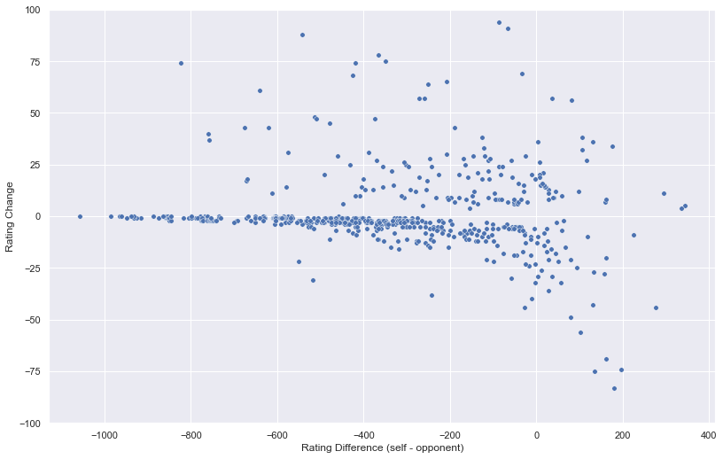

```python
sns.scatterplot(data=df, x=df["Rating"] - df["OpponentRating"], y="RatingChange", s=30)
sns.set(rc={'figure.figsize':(12, 8)})

#plt.xlim(-600, 600)
plt.ylim(-100, 100)
#plt.legend()
plt.xlabel("Rating Difference (self - opponent)")
plt.ylabel("Rating Change")
#plt.title("")
plt.show()
```

### 3.3.1 User Rating By Date

**Goal**: View user's rating over time.

**Note**: X axis is not linearly proportional over time! Each x-tick represents a day where the user played at least one game, so this is more like user rating over games played.

**Potential error**: the below graph may not output the x-axis (date) in the correct order. If so, then run the cell below it, although it is a worse version of this below graph, in my opinion. The main difference is the below graph shows rating change over units of games played, while the other one shows rating change over units of time.

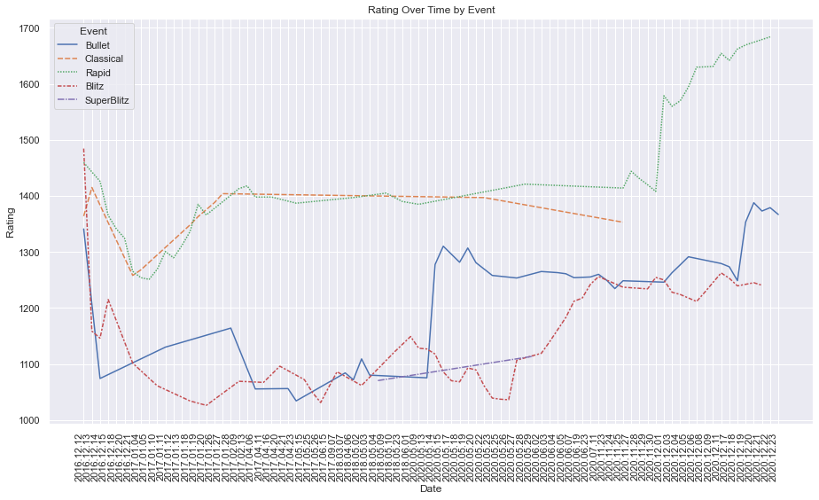

```python
plt.figure(figsize=(13,8))
urot = df.copy(deep = True)
urot = urot.sort_values(by="UTCDate", ascending=True)
ax = sns.lineplot(data=urot, x="UTCDate", y="Rating", hue="Event", style="Event", ci=None, sort=False)
plt.draw()
ax.set_xticklabels(ax.get_xticklabels(), rotation=90, ha="right")

plt.xlabel("Date")
plt.ylabel("Rating")
plt.title("Rating Over Time by Event")
plt.tight_layout()
plt.show()
```

### 3.3.2 User Rating Over Time

**(Optional)**: If the cell above ran fine, then you don't really need to run this. This graphs based on time as a numeric value, so if you play many of your games in one short time period, then it'll appear as a big jump in rating on the graph (assuming there is a rating change). The x-axis also might not be printed properly, so if something like 20185 or 20180 shows up, interpret it as the middle of 2018 or the beginning of 2018.

**Goal**: Same as 3.3.1.

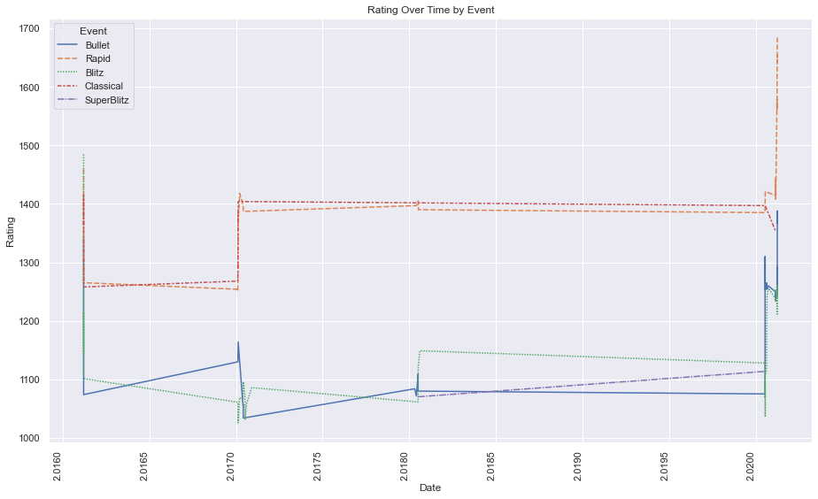

```python
plt.figure(figsize=(13,8))
urot = df.copy(deep = True)
urot["fulldate"] = urot["Year"] * 10000 + urot["Month"] * 100 + urot["Day"]

ax = sns.lineplot(data=urot, x="fulldate", y="Rating", hue="Event", style="Event", ci=None, sort=True)
plt.draw()
ax.set_xticklabels(ax.get_xticklabels(), rotation=90, ha="right")

plt.xlabel("Date")
plt.ylabel("Rating")
plt.title("Rating Over Time by Event")
plt.tight_layout()
plt.show()
```

### 3.4 Performance against opponent rating

**Goal**: View user's winrate against a certain rating.

**Note**: The rating is represented as a range, since otherwise a winrate can't be calculated. There are two functions:

perfELO_reg() : predicts winrate based on opponent rating.

perf_ELO() : shows winrate based on opponent rating.

**Reminder**: From section 2, you can also use the following tables: bullet, blitz, rapid, classical, white, black. The first four represent games played only in that game mode, and the last two represent all games where you played as that side. This applies to all functions where you can provide an argument, but it is especially useful here because ratings are not equivalent across game modes!

Set how wide you want each rating group to be (the range).

```python
N = 50
```

```python
def perf_ELO_reg(df):
    plt.figure(figsize=(13,8))
    ax = sns.regplot(x=df["OpponentRating"], y=(df["Win"] + 0.5 * df["Draw"]) / (df["Win"] + df["Loss"] + df["Draw"]),
                     x_bins=10)
    plt.draw()
    ax.set_xticklabels(ax.get_xticklabels(), rotation=90, ha="right")

    plt.xlabel("Opponent ELO")
    plt.ylabel("PPG")
    plt.title("Performance against Opponent Rating")
    plt.tight_layout()
    plt.show()
```

```python
def perf_ELO(df):
    mini = min(df["OpponentRating"])
    mini = round(mini / 50) * 50
    maxi = max(df["OpponentRating"])
    rating, score, count = [], [], []
    while (mini <= maxi):
        temp = df[(df["OpponentRating"] >= mini) & (df["OpponentRating"] < mini + N)]

        ppg = (np.sum(temp["Win"]) + 0.5 * np.sum(temp["Draw"])) / (
            np.sum(temp["Win"]) + np.sum(temp["Loss"]) + np.sum(temp["Draw"]))

        rating.append(str(mini) + "-" + str(mini + N))
        score.append(ppg)
        count.append(len(temp))

        mini += N

    plt.figure(figsize=(13,8))
    ax = sns.scatterplot(x=rating, y=score, size=count)
    plt.draw()
    ax.set_xticklabels(ax.get_xticklabels(), rotation=90, ha="right")

    plt.xlabel("Opponent ELO")
    plt.ylabel("PPG")
    plt.title("Performance against Opponent Rating")
    plt.tight_layout()
    plt.show()
```

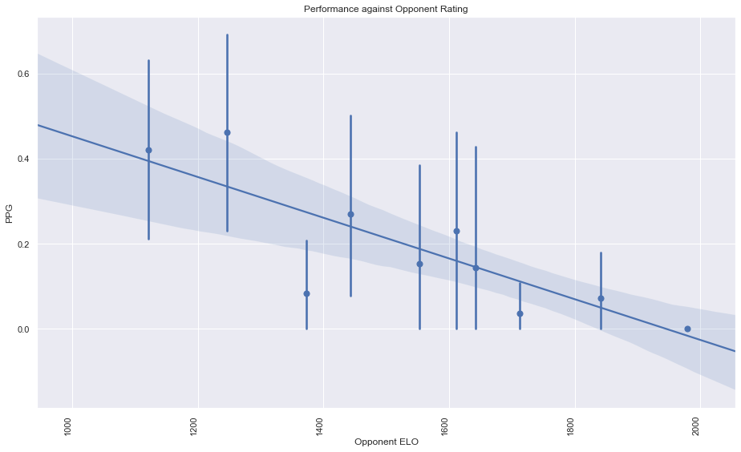

```python
perf_ELO_reg(blitz)
```

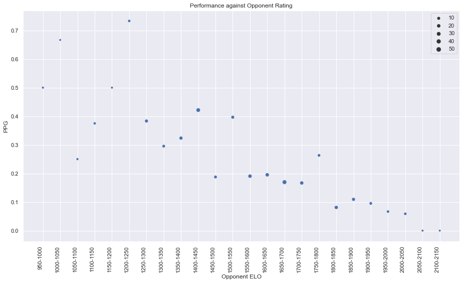

```python
perf_ELO(df)
```

## 4. Openings

Covers:

**4.1**. Openings played as White/Black

**4.2**. Opening Variations

### 4.1 Openings played as White/Black

**Goal**: Provides a list of the openings a user has played as White or Black, and sorts them in order by openings played most often (GP = Games Played). Displays the top 20 openings for both sides. There are many columns that the user can draw information from. What to look for:

1. *REL*: Shows the average points per game (PPG) scored using this opening minus the average points per game (PPG) of the user over all their openings on that side. Essentially, it represents how good the user plays that opening relative to all their other ones.
1. *Rating Difference*: The part that may invalidate REL. Some players choose to play different openings against different ratings, typically playing more "drawish" or closed openings against better players and more aggressive or open openings against lower rated players. If you constantly lose with an opening because you're only playing it against higher rated players, that doesn't mean you're playing the opening worse compared to your other openings.
1. *Rating Change (average per game) / Total Rating Gain*: The most important columns in my opinion. It combines both REL and rating difference to show how successful your opening is in your ELO/rating. Your expected rating gain against any opponent and any rating should be 0, because the rating system factors in how much better/worse an opponent is.
1. *Moves*: Do games played under this opening tend to be long or short? If you are bad with fast games, you might want to consider picking openings that have a shorter number of moves on average.
1. *W/L/D*: Probably the first thing you'll pick up on, anyway.

```python
def opening_list(data):
    # groupby
    df = data[["Opening", "Win", "Loss", "Draw", "Moves", "Event",
              "Variation", "Rating", "OpponentRating",
              "RatingChange"]].groupby("Opening").agg({"Win":np.sum, "Loss":np.sum,
                                                    "Draw":np.sum, "Moves":np.average,
                                                    "Event":lambda x: x.value_counts().index[0],
                                                    "Variation": lambda x: x.value_counts().index[0],
                                                    "Rating":np.average, "OpponentRating":np.average,
                                                    "RatingChange":np.average})
    # create count col
    df["GP"] = df["Win"] + df["Loss"] + df["Draw"]
    # sort by count
    df = df.sort_values(by = "GP", ascending = False)
    # total ELO gained
    df["Total Rating Gain"] = (df["GP"] * df["RatingChange"]).astype(int)
    # PPG (points per game)
    df["PPG"] = round((df["Win"] + 0.5 * df["Draw"]) / (df["Win"] + df["Loss"] + df["Draw"]), 3)
    # comparison to average PPG as black
    avg_ppg = round((np.sum(data["Win"]) + 0.5 * np.sum(data["Draw"])) /
                    (np.sum(data["Win"]) + np.sum(data["Loss"]) + np.sum(data["Draw"])), 3)
    df["REL"] = df["PPG"] - avg_ppg
    # round stuff
    df["Moves"] = round(df["Moves"], 1)
    df["Rating"] = round(df["Rating"]).astype(int)
    df["OpponentRating"] = round(df["OpponentRating"]).astype(int)
    df["Rating Difference"] = df["Rating"] - df["OpponentRating"]
    df["RatingChange"] = round(df["RatingChange"], 2)
    # reorder columns
    df = df[["GP", "Moves", "Win", "Loss", "Draw", "PPG", "REL", "Total Rating Gain", "Rating Difference",
            "RatingChange", "Variation", "Event"]]
    df = df.rename(columns={"Event":"Most played in", "Variation":"Most common variation"})

    return df
```

```python
opening_list(white).head(20)
```

| Opening | GP | Moves | Win | Loss | Draw | PPG | REL | Total Rating Gain | Rating Difference | RatingChange | Most common variation | Most played in |
| --- | --- | --- | --- | --- | --- | --- | --- | --- | --- | --- | --- | --- |
| Sicilian Defense | 33 | 27.5 | 6 | 27 | 0 | 0.182 | -0.072 | -24 | -361 | -0.73 | Main Line | Bullet |
| Caro-Kann Defense | 19 | 37.6 | 1 | 15 | 3 | 0.132 | -0.122 | -36 | -339 | -1.89 | Main Line | Bullet |
| Scandinavian Defense | 18 | 25.9 | 6 | 12 | 0 | 0.333 | 0.079 | 41 | -399 | 2.28 | Mieses-Kotroc Variation | Bullet |
| Four Knights Game | 16 | 23.9 | 5 | 11 | 0 | 0.312 | 0.058 | 28 | -399 | 1.75 | Italian Variation | Bullet |
| French Defense | 15 | 22.5 | 5 | 9 | 1 | 0.367 | 0.113 | 158 | -279 | 10.53 | Knight Variation | Bullet |
| Philidor Defense | 15 | 23.0 | 2 | 13 | 0 | 0.133 | -0.121 | -122 | -241 | -8.20 | Main Line | Blitz |
| Giuoco Piano | 12 | 23.6 | 1 | 9 | 2 | 0.167 | -0.087 | -98 | -268 | -8.17 | Main Line | Bullet |
| Pirc Defense | 11 | 32.9 | 3 | 8 | 0 | 0.273 | 0.019 | -18 | -340 | -1.64 | Main Line | Bullet |
| King's Pawn Game | 11 | 20.9 | 4 | 6 | 1 | 0.409 | 0.155 | 9 | -83 | 0.82 | Busch-Gass Gambit | Bullet |
| Queen's Pawn Game | 10 | 28.6 | 3 | 7 | 0 | 0.300 | 0.046 | 65 | -335 | 6.50 | Mason Variation | Bullet |
| Vienna Game | 7 | 25.4 | 2 | 5 | 0 | 0.286 | 0.032 | -27 | -155 | -3.86 | Vienna Gambit | Blitz |
| Ruy Lopez | 7 | 21.1 | 3 | 4 | 0 | 0.429 | 0.175 | 190 | -220 | 27.14 | Exchange Variation, Keres Variation | Rapid |
| Russian Game | 7 | 26.9 | 2 | 5 | 0 | 0.286 | 0.032 | 54 | -327 | 7.71 | Three Knights Game | Bullet |
| Alekhine Defense | 6 | 25.7 | 0 | 6 | 0 | 0.000 | -0.254 | -109 | -218 | -18.17 | Main Line | Blitz |
| King's Knight Opening | 6 | 35.0 | 1 | 5 | 0 | 0.167 | -0.087 | -1 | -202 | -0.17 | Konstantinopolsky | Bullet |
| Zukertort Opening | 6 | 31.7 | 2 | 4 | 0 | 0.333 | 0.079 | 35 | -424 | 5.83 | Main Line | Bullet |
| Italian Game | 6 | 25.7 | 2 | 4 | 0 | 0.333 | 0.079 | 6 | -273 | 1.00 | Anti-Fried Liver Defense | Blitz |
| Modern Defense | 5 | 41.8 | 1 | 4 | 0 | 0.200 | -0.054 | 4 | -417 | 0.80 | Main Line | Bullet |
| Van't Kruijs Opening | 5 | 28.0 | 1 | 4 | 0 | 0.200 | -0.054 | 16 | -438 | 3.20 | Main Line | Bullet |
| Nimzowitsch Defense | 4 | 20.2 | 2 | 2 | 0 | 0.500 | 0.246 | 113 | -669 | 28.25 | Main Line | Bullet |

```python
opening_list(black).head(20)
```

| Opening | GP | Moves | Win | Loss | Draw | PPG | REL | Total Rating Gain | Rating Difference | RatingChange | Most common variation | Most played in |
| --- | --- | --- | --- | --- | --- | --- | --- | --- | --- | --- | --- | --- |
| Italian Game | 37 | 23.2 | 10 | 26 | 1 | 0.284 | 0.047 | 94 | -229 | 2.54 | Giuoco Pianissimo, Italian Four Knights Variation | Bullet |
| King's Pawn Game | 28 | 25.4 | 10 | 16 | 2 | 0.393 | 0.156 | 60 | -194 | 2.14 | Leonardis Variation | Bullet |
| Queen's Pawn Game | 28 | 35.6 | 2 | 23 | 3 | 0.125 | -0.112 | 99 | -408 | 3.54 | Chigorin Variation | Bullet |
| Scotch Game | 26 | 24.6 | 5 | 20 | 1 | 0.212 | -0.025 | 25 | -327 | 0.96 | Main Line | Bullet |
| Bishop's Opening | 19 | 30.9 | 4 | 13 | 2 | 0.263 | 0.026 | -67 | -251 | -3.53 | Main Line | Bullet |
| Ruy Lopez | 18 | 25.7 | 4 | 13 | 1 | 0.250 | 0.013 | 42 | -400 | 2.33 | Morphy Defense, Caro Variation | Bullet |
| Englund Gambit | 17 | 26.1 | 6 | 11 | 0 | 0.353 | 0.116 | 39 | -245 | 2.29 | Main Line | Bullet |
| Queen's Gambit Declined | 11 | 24.9 | 0 | 10 | 1 | 0.045 | -0.192 | -22 | -578 | -2.00 | Marshall Defense | Bullet |
| Four Knights Game | 11 | 25.0 | 4 | 7 | 0 | 0.364 | 0.127 | 146 | -353 | 13.27 | Italian Variation | Bullet |
| Sicilian Defense | 9 | 28.4 | 4 | 4 | 1 | 0.500 | 0.263 | -44 | -171 | -4.89 | Old Sicilian | Bullet |
| King's Gambit Declined | 9 | 30.9 | 1 | 8 | 0 | 0.111 | -0.126 | -46 | -380 | -5.11 | Queen's Knight Defense | Bullet |
| English Opening | 8 | 35.2 | 1 | 7 | 0 | 0.125 | -0.112 | -4 | -446 | -0.50 | King's English Variation, Two Knights Variatio... | Rapid |
| Bird Opening | 6 | 27.2 | 1 | 5 | 0 | 0.167 | -0.070 | -252 | -418 | -42.00 | Main Line | Bullet |
| Ponziani Opening | 6 | 29.3 | 3 | 3 | 0 | 0.500 | 0.263 | 36 | -120 | 6.00 | Jaenisch Counterattack | Bullet |
| King's Gambit | 5 | 35.0 | 1 | 2 | 2 | 0.400 | 0.163 | 46 | -388 | 9.20 | Main Line | Bullet |
| Van't Kruijs Opening | 5 | 33.8 | 1 | 4 | 0 | 0.200 | -0.037 | 11 | -421 | 2.20 | Main Line | Bullet |
| French Defense | 5 | 38.2 | 0 | 5 | 0 | 0.000 | -0.237 | -203 | -413 | -40.60 | Main Line | Blitz |
| King's Knight Opening | 5 | 19.6 | 4 | 1 | 0 | 0.800 | 0.563 | 44 | 2 | 8.80 | Normal Variation | Bullet |
| Three Knights Opening | 4 | 25.8 | 0 | 4 | 0 | 0.000 | -0.237 | -6 | -588 | -1.50 | Main Line | Bullet |
| Vienna Game | 4 | 26.0 | 1 | 3 | 0 | 0.250 | 0.013 | -2 | -319 | -0.50 | Stanley Variation, Reversed Spanish | Bullet |

### 4.2 Opening Variations played as White/Black

**Goal**: Any particular variation of an opening suddenly come to mind after that long opening list? Or perhaps you want to compare how you do using all the variations of the Sicilian?

**Input**: Type in which side you are playing from, and what opening you would like to see.

ex. Typing in "Black" and "Sicilian Defense" will show games where you played the Sicilian as black.

```python
# "White" or "Black"
side = "Black"

# Check spelling and capitalization!
opening = "Italian Game"
```

```python
def opening_variation_list(data):
    # groupby
    df = data[["Win", "Loss", "Draw", "Moves", "Event",
              "Variation", "Rating", "OpponentRating",
              "RatingChange"]].groupby("Variation").agg({"Win":np.sum, "Loss":np.sum,
                                                    "Draw":np.sum, "Moves":np.average,
                                                    "Event":lambda x: x.value_counts().index[0],
                                                    "Rating":np.average, "OpponentRating":np.average,
                                                    "RatingChange":np.average})
    # create count col
    df["GP"] = df["Win"] + df["Loss"] + df["Draw"]
    # sort by count
    df = df.sort_values(by = "GP", ascending = False)
    # total ELO gained
    df["Total Rating Gain"] = (df["GP"] * df["RatingChange"]).astype(int)
    # PPG (points per game)
    df["PPG"] = round((df["Win"] + 0.5 * df["Draw"]) / (df["Win"] + df["Loss"] + df["Draw"]), 3)
    # comparison to average PPG as black
    avg_ppg = round((np.sum(data["Win"]) + 0.5 * np.sum(data["Draw"])) /
                    (np.sum(data["Win"]) + np.sum(data["Loss"]) + np.sum(data["Draw"])), 3)
    df["REL"] = df["PPG"] - avg_ppg
    # round stuff
    df["Moves"] = round(df["Moves"], 1)
    df["Rating"] = round(df["Rating"]).astype(int)
    df["OpponentRating"] = round(df["OpponentRating"]).astype(int)
    df["Rating Difference"] = df["Rating"] - df["OpponentRating"]
    df["RatingChange"] = round(df["RatingChange"], 2)
    # reorder columns
    df = df[["GP", "Moves", "Win", "Loss", "Draw", "PPG", "REL", "Total Rating Gain", "Rating Difference",
            "RatingChange", "Event"]]
    df = df.rename(columns={"Event":"Most played in"})

    print()
    print(color.BOLD + "OPENING: " + opening + " AS " + side)
    return df


opening_variation_list(df[df["Color"] == side][df["Opening"] == opening])
```

```
OPENING: Italian Game AS Black
```

| Variation | GP | Moves | Win | Loss | Draw | PPG | REL | Total Rating Gain | Rating Difference | RatingChange | Most played in |
| --- | --- | --- | --- | --- | --- | --- | --- | --- | --- | --- | --- |
| Giuoco Pianissimo, Italian Four Knights Variation | 5 | 20.4 | 2 | 3 | 0 | 0.400 | 0.116 | 31 | -296 | 6.20 | Bullet |
| Two Knights Defense, Traxler Counterattack, Knight Sacrifice Line | 4 | 25.8 | 2 | 2 | 0 | 0.500 | 0.216 | 72 | -169 | 18.00 | Bullet |
| Giuoco Pianissimo, Normal | 3 | 17.7 | 1 | 2 | 0 | 0.333 | 0.049 | 1 | -186 | 0.33 | Rapid |
| Two Knights Defense | 3 | 25.7 | 2 | 1 | 0 | 0.667 | 0.383 | 94 | -308 | 31.33 | Bullet |
| Classical Variation, Giuoco Pianissimo | 3 | 43.3 | 1 | 2 | 0 | 0.333 | 0.049 | 23 | -346 | 7.67 | Blitz |
| Classical Variation, Center Attack | 2 | 16.0 | 0 | 2 | 0 | 0.000 | -0.284 | -28 | -53 | -14.00 | Bullet |
| Main Line | 2 | 28.5 | 1 | 1 | 0 | 0.500 | 0.216 | 11 | -440 | 5.50 | Bullet |
| Classical Variation, Albin Gambit | 2 | 17.5 | 0 | 2 | 0 | 0.000 | -0.284 | -12 | -253 | -6.00 | Bullet |
| Two Knights Defense, Knight Attack | 2 | 11.5 | 1 | 0 | 1 | 0.750 | 0.466 | 28 | 113 | 14.00 | Rapid |
| Two Knights Defense, Modern Bishop's Opening | 2 | 28.5 | 0 | 2 | 0 | 0.000 | -0.284 | -43 | -108 | -21.50 | Bullet |
| Two Knights Defense, Polerio Defense, Bishop Check Line | 2 | 17.0 | 0 | 2 | 0 | 0.000 | -0.284 | -14 | -208 | -7.00 | Bullet |
| Evans Gambit, McDonnell Defense | 1 | 22.0 | 0 | 1 | 0 | 0.000 | -0.284 | -7 | -32 | -7.00 | Bullet |
| Scotch Gambit | 1 | 17.0 | 0 | 1 | 0 | 0.000 | -0.284 | -1 | -505 | -1.00 | Bullet |
| Two Knights Defense, Max Lange Attack | 1 | 11.0 | 0 | 1 | 0 | 0.000 | -0.284 | -2 | -694 | -2.00 | Blitz |
| Two Knights Defense, Polerio Defense, Suhle Defense | 1 | 28.0 | 0 | 1 | 0 | 0.000 | -0.284 | -3 | -371 | -3.00 | Blitz |
| Two Knights Defense, Traxler Counterattack | 1 | 46.0 | 0 | 1 | 0 | 0.000 | -0.284 | -14 | 18 | -14.00 | Rapid |
| Two Knights Defense, Traxler Counterattack, King March Line | 1 | 19.0 | 0 | 1 | 0 | 0.000 | -0.284 | -2 | -308 | -2.00 | Bullet |
| Anti-Fried Liver Defense | 1 | 12.0 | 0 | 1 | 0 | 0.000 | -0.284 | -40 | -11 | -40.00 | Bullet |

## 5. Personal Opening Tree

Something similar to what you'd find on openingtree.com or lichess.com/analysis, but obviously a downscaled version in nearly every aspect.

The personal opening tree allows you to type in moves and shows all next moves you or your opponents played with the frequency each occurred at and their winrates; it also shows the opponent's ratings and stockfish ratings behind every move.

However, something that I found out only after I implemented this was that the eval for the exact same positions are often different on the PGN file! For example, 1. e4 has an eval of +0.03 on some games, while that exact same first move has an eval of +0.24 on other games. Anyway, if you really wanted a proper engine score, you could just use openingtree or lichess analysis, since they're much easier to use and much more accurate.

**Goal**: This is more helpful for seeing moves you played in the past (or your opponents), and cross-checking what you play versus what your opponent plays. Also, looking at it from your opponent's perspective might tell you moves lower rated players like to play versus higher rated players in the same position.

**Problem**: Disregard the rating related columns in this table. The ratings are wildly inaccurate right now as I was forced to take the max of all values given for rating related variables. Switching to aggregating with the median may reduce the error quite significantly, but it will never guarantee the fact that the rating may still be far off given the input. As this isn't the highlight of the personal opening tree and there was no potential for it to be perfect, I've stalled on converting to a median, which proved to be harder than I had expected. Might come back to it after I finish the rest.

**Note**: The opening tree will show blue on your move and red on theirs.

**Input**: *Check 2 cells down*.

```python
# Not being used right now.
# Aggregation function for stockfish related stuff.
def middle(a):
    b = []
    a = (a.reset_index().iloc[:,1])
    for i in np.arange(len(a)):
        if (a[i] != -100):
            b.append(a[i])

    if (b == []):
        b = [-100]
    return np.median(b)

def opening_tree(df, side, lst):
    if ((side != "White") & (side != "Black")):
        raise ValueError("Color must be black or white")

    self = df[df["Color"] == side].reset_index()
    if (side == "White"):
        opp = df[df["Color"] == "Black"].reset_index()
    else:
        opp = df[df["Color"] == "White"].reset_index()

    white = 1
    argIndex = 0

    for i in np.arange(len(lst) + 1):
        arr = []
        droplist = []

        # Update self tree
        if (white == 1):
            for j in np.arange(len(self["WhiteMoves"])):
                if (len(self["WhiteMoves"][j]) <= argIndex):
                    droplist.append(j)
                elif ((i != len(lst)) and (self["WhiteMoves"][j][argIndex] != lst[i])):
                    droplist.append(j)
        else:
            for j in np.arange(len(self["BlackMoves"])):
                if (len(self["BlackMoves"][j]) <= argIndex):
                    droplist.append(j)
                elif ((i != len(lst)) and (self["BlackMoves"][j][argIndex] != lst[i])):
                    droplist.append(j)
            if (i != len(lst)):
                argIndex += 1


        self = self.drop(df.index[droplist]).reset_index().drop(["level_0"], axis=1)
        white = 1 - white

    white = 1 - white
    if (white == 0):
        sadge = "BLACK"
        orient = "Negative"
    else:
        sadge = "WHITE"
        orient = "Positive"

    # Table modifications
    if (white == 1):
        # Random set
        self["Current Rating"] = self["BlackRating"]
        stockfish = "WhiteStockfish"
        moves = "WhiteMoves"
        ratin = "WhiteRating"
        antistockfish = "BlackStockfish"
    else:
        # Random set
        self["Current Rating"] = self["WhiteRating"]
        stockfish = "BlackStockfish"
        moves = "BlackMoves"
        ratin = "BlackRating"
        antistockfish = "WhiteStockfish"

    for j in np.arange(len(self[moves])):
        self[moves][j] = self[moves][j][argIndex]
        if (len(self[stockfish][j]) != 0):
            self[stockfish][j] = self[stockfish][j][argIndex]
            self[ratin][j] = self[ratin][j][argIndex]
            # Current rating
            if (moves == "WhiteMoves"):
                self["Current Rating"][j] = self[antistockfish][j][argIndex - 1]
            else:
                self["Current Rating"][j] = self[antistockfish][j][argIndex]
        else:
            self[stockfish][j] = -100
            self[ratin][j] = -100
            # Current rating
            self["Current Rating"][j] = -100


    # Since evals are different for the same moves sometimes, I switched from aggregating stockfish
    # stats using max to using median. This requires all rating related series to have dtype
    # int64, as np.median was not working for the aggregation and I was stuck for a long time.
    self[stockfish] = self[stockfish].astype(int)


    self_df = self[["Win", "Loss", "Draw", "Result", "Moves",
              "Rating", "OpponentRating",
                moves, stockfish,
                 ratin, "Opening",
                "Current Rating"]].groupby(moves).agg({"Opening":len,
                                                    "Win":np.sum, "Loss":np.sum,
                                                    "Draw":np.sum, "Result": np.average,
                                                    #"Opponent":lambda x: tuple(x),
                                                    "Rating":np.average, "OpponentRating":np.average,
                                                    "Moves":np.average,
                                                       "Current Rating":max,
                                                    ratin:max,  stockfish:max })
    # Some adjustments
    self_df["Rating"] = round(self_df["Rating"], 1)
    self_df["OpponentRating"] = round(self_df["OpponentRating"], 1)
    self_df["Moves"] = round(self_df["Moves"], 1)
    self_df["Result"] = round(self_df["Result"], 3)
    self_df = self_df.rename(columns={"Opening":"Count", ratin:"EVAL",
                                     stockfish:"Rating After Move"}).sort_values("Count", ascending=False)
    self_df = self_df.replace(-100, "N/A")


    #return self_df.to_html('temp.html')

    print("")
    print(color.YELLOW + color.UNDERLINE + color.BOLD + USERNAME + " PLAYING " + side + color.END)
    print("")
    print("")
    if (sadge.lower() == side.lower()):
        print(color.BLUE + color.UNDERLINE + color.BOLD + sadge + " TO MOVE (" + orient + " rating is good)" + color.END)
    else:
        print(color.RED + color.UNDERLINE + color.BOLD + sadge + " TO MOVE (" + orient + " rating is good)" + color.END)
    display(self_df)
```

### Personal Opening Tree

**INPUT**:

SIDE: Enter what side you played on with "White" or "Black".

MOVES: Enter the sequence of moves so far, ex. ["e4", "e5", "Nf3"]

```python
side = "White"
moves = ["e4", "e5"]

opening_tree(df, side, moves)
```

```
KimiNoUso PLAYING White


WHITE TO MOVE (Positive rating is good)
```

| WhiteMoves | Count | Win | Loss | Draw | Result | Rating | OpponentRating | Moves | Current Rating | EVAL | Rating After Move |
| --- | --- | --- | --- | --- | --- | --- | --- | --- | --- | --- | --- |
| Nf3 | 84 | 19 | 63 | 2 | 0.238 | 1288.2 | 1559.6 | 24.5 | 0.42 | 0.06 | 0 |
| Nc3 | 7 | 2 | 5 | 0 | 0.286 | 1267.1 | 1421.9 | 25.4 | N/A | N/A | N/A |
| Bc4 | 4 | 4 | 0 | 0 | 1.000 | 1312.8 | 1447.2 | 27.2 | N/A | N/A | N/A |
| d4 | 3 | 0 | 3 | 0 | 0.000 | 1324.0 | 1452.0 | 22.7 | N/A | N/A | N/A |
| Ne2 | 1 | 0 | 0 | 1 | 0.500 | 1048.0 | 1128.0 | 13.0 | N/A | N/A | N/A |
| Qh5 | 1 | 0 | 1 | 0 | 0.000 | 1249.0 | 1479.0 | 18.0 | N/A | N/A | N/A |
| c3 | 1 | 0 | 1 | 0 | 0.000 | 1371.0 | 1677.0 | 30.0 | N/A | N/A | N/A |

## 6. Engine Evaluation

Everything to do with engine evaluations.

Covers:

**6.0**. Setup

**6.1**. Engine Evaluation against Opponent

**6.2**. Opening vs Engine Evaluation

**6.3**. Opening Variation vs Engine Evaluation

6.3.1. Graphed against opening

6.3.2. Graphed by variation only

**6.4**. Engine Evaluation on Piece Moved

**6.5**. Specified Eval + Move Number Statistics

**Note**: Reminder that the analysis in this section isn't based on all the user's games, but only the subset that have engine evaluations in them.

### 6.0 Setup

It's likely that many PGN files won't come with many games that have %eval (stockfish computer analysis in them), so filter the csv to only contain games that have stockfish evaluation in them. Run the cell below.

```python
def filter_stockfish(df):
    droplist = []
    for i in np.arange(len(df["WhiteStockfish"])):
        if (df["WhiteStockfish"][i] == []):
            droplist.append(i)

    df = df.drop(df.index[droplist]).reset_index()
    return df

stock_df = filter_stockfish(df)
```

This next function is needed for sections 6.1 - 6.3.

```python
def stockfish_fn(df, title, child, title2="", variation=""):

    # Build "empty" scores and moves list of right sizes
    scores = []
    moves = []
    player = []
    for j in np.arange(len(df["WhiteStockfish"])):
        scores.append([])
        moves.append([])
        player.append(0)

    for j in np.arange(len(df["WhiteStockfish"])):
        flipper = 0
        for i in np.arange(len(df["WhiteStockfish"][j] + df["BlackStockfish"][j])):
            if (flipper == 0):
                scores[j].append(df["WhiteStockfish"][j][int(i / 2)])
                moves[j].append(str(int(i / 2) + 1) + "W")
            else:
                scores[j].append(df["BlackStockfish"][j][int(i / 2)])
                moves[j].append(str(int(i / 2) + 1) + "_B")
            flipper = 1 - flipper

        if (df["Color"][j] == "White"):
            player[j] = "White"
        else:
            player[j] = "Black"

    #Plotting
    plt.figure(figsize=(13,8))

    for i in np.arange(len(df["WhiteStockfish"])):
        if (player[i] == "White"):
            graphColor = "blue"
        else:
            graphColor = "red"
        if (child == "opvar"):
            if (df["Variation"][i] == variation):
                graphColor = "cyan"
        sns.lineplot(x=moves[i], y=scores[i], color=graphColor, sort=False)


    plt.xticks(rotation=90)
    plt.draw()

    plt.ylim(-16, 16)
    plt.xlabel("Move number")
    plt.ylabel("Stockfish Eval")
    if (child == "opp"):
        plt.title("Rating by Move against " + title)
    elif (child == "opening" or child == "opvar"):
        plt.title("Rating by Move for opening " + title + " as " + title2)
    #plt.tight_layout()
    plt.show()
```

### 6.1 Engine Evaluation against Opponent

**Goal**: Analyze patterns against a specific player. For example, does the user perform worse in the early game against this player?

**Important**: blue lines represent the user playing as White (positive ratings are winning), while red lines represent the user playing as Black (negative ratings are winning).

**Input**: Type in opponent name below.

```python
# ex. Opponent_name = "HikaruGM"

Opponent_name = "thatprogrammer"
```

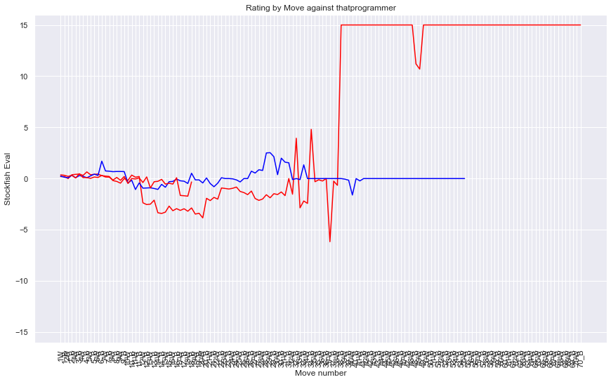

```python
def stockfish_opp(df, opp):
    df = df[df["Opponent"] == opp].reset_index().drop(["level_0"], axis=1)
    stockfish_fn(df, opp, "opp")

stockfish_opp(stock_df, Opponent_name)
```

### 6.2 Opening vs Engine Evaluation

**Goal**: Analyze the patterns for how a game plays out with a specific opening. Is there any point in the game where the user often holds a lead but loses it? What typically happens after the opening finishes?

**Input**: Type in which color the user plays as and what opening they play.

```python
# ex. Opening = "Sicilian Defense"

Opening = "Four Knights Game"

# "White" or "Black"
User_plays_as = "White"
```

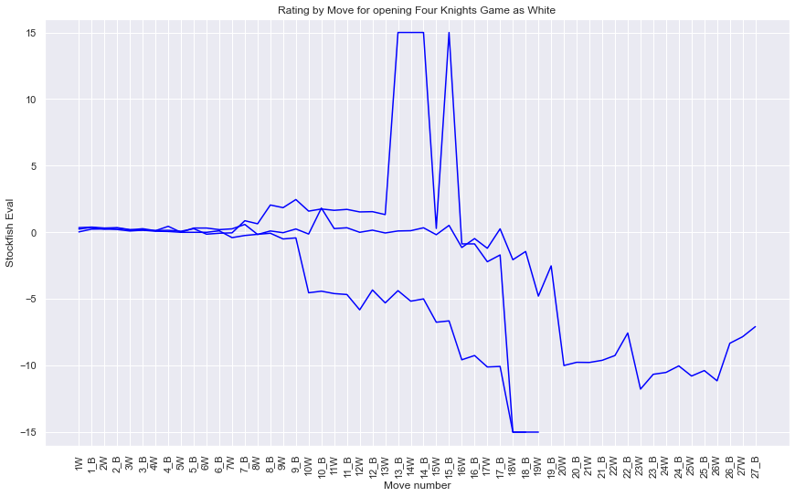

```python
def stockfish_opening(df, opening, User_plays_as):
    df = df[df["Color"] == User_plays_as]
    df = df[df["Opening"] == opening].reset_index().drop(["level_0"], axis=1)
    stockfish_fn(df, opening, "opening", User_plays_as)

stockfish_opening(stock_df, Opening, User_plays_as)
```

### 6.3 Opening Variation vs Engine Evaluation

Considers all games of a specific opening variation (more in-depth version of the graphs from above).

#### There are two functions below:

**Function 1**. Graph all rating graphs under an opening, but have the ones played under the specified variation in CYAN. Same runtime as the graphs above.

**Goal**: Compare the game flow for an opening variation versus all other variations in that opening.

**Function 2**. ONLY graph games with the given opening and variation.

**Goal**: Same as 6.2, but for an opening variation.

#### Important: the variation is included in the PGN file as the part after the ":". If no ":" appears for a game entry, then the variation is simply considered "Main Line".

**Input**: type in which color the user plays as and what opening/variation below, then run the cell after.

```python
# ex. Opening = "Four Knights Game"
# ex. Variation = "Italian Variation"

Opening = "Four Knights Game"
Variation = "Italian Variation"

# "White" or "Black"
User_plays_as = "White"
```

**Function 1**: graphs all games under the opening but the ones under the variation are colored in **CYAN**.

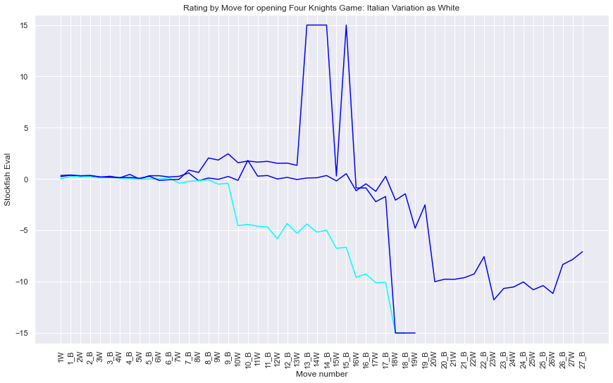

```python
def stockfish_opening_variation(df, opening, variation, User_plays_as):
    df = df[df["Color"] == User_plays_as]
    df = df[df["Opening"] == opening].reset_index().drop(["level_0"], axis=1)
    stockfish_fn(df, opening + ": " + variation, "opvar", User_plays_as, variation)

stockfish_opening_variation(stock_df, Opening, Variation, User_plays_as)
```

**Function 2**: graphs ONLY games under the variation in addition to opening.

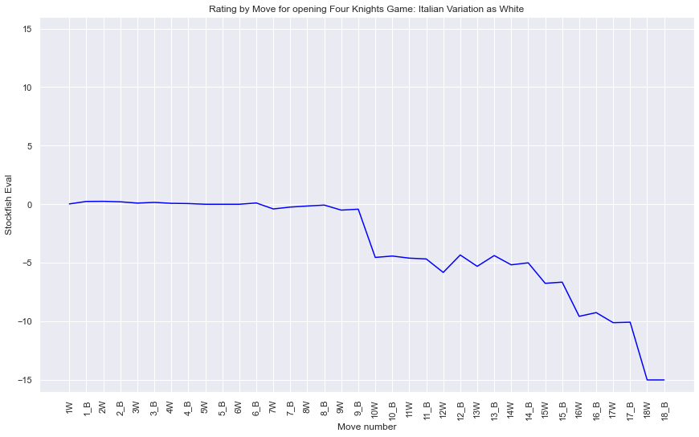

```python
def stockfish_opening_variation_iso(df, opening, variation, User_plays_as):
    df = df[df["Color"] == User_plays_as]
    df = df[df["Opening"] == opening]
    df = df[df["Variation"] == variation].reset_index().drop(["level_0"], axis=1)
    stockfish_fn(df, opening + ": " + variation, "opening", User_plays_as, variation)

stockfish_opening_variation_iso(stock_df, Opening, Variation, User_plays_as)
```

### 6.4 Engine Evaluation on Piece Moved

**Goal**: What piece does the user blunder with the most? The table shows what pieces the user is good/bad with, and a "Total Gain" score that indicates the total amount of rating the user has gained on their opponents over all their piece moves. The graph shows where in the game they tend to blunder their pieces.

**Note**: It is better to have higher rating as White, and lower as Black. The reason it will be all negative for White and all positive for Black is because it is not possible to increase your evaluation score with a move (at best, you can only maintain the same engine evaluation). Of course, there will show instances where this happened because the data is not perfect.

(Optional) Note: On a more technical note, the "Total Gain" score is merely an estimate, not the real gain you get across all moves. The true total gain could be calculated by multiplying the user_count *avg_user_rating - opponent_count* avg_opponent_rating, but if the user tends to play much more bishop moves, then the total gain will probably be worse for the user (why? see above note). That's not because the user is worse with the piece but because they play it more often. Sure, the average rating already reflects this, so why does it matter? My intentions behind showing the "Total Gain" was to give users an idea of significant their average loss was compared to their opponents by factoring in how often the piece is played from both sides. For example, making mistakes on castling should result in low total gain because it can only be played once per game. I did not want to factor in how much a user chooses to move a piece vs how often their opponent does as well.

**Input**: Type in which color the user plays as and what opening they play.

```python
# "White" or "Black"
user_color = "White"
```

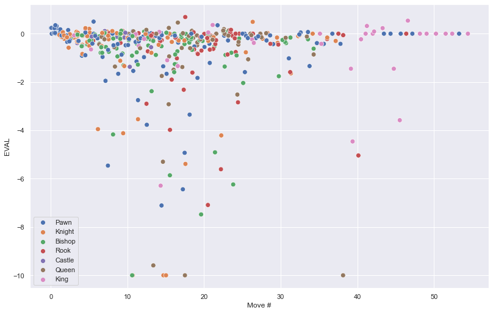

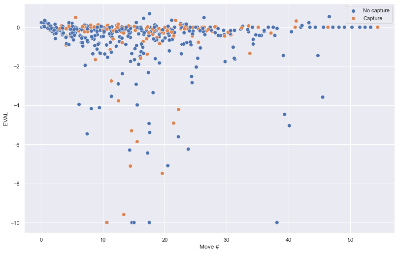

```
USER IS: White
| Piece      |   Avg Rating |   Avg Opponent Rating |   Total Gain |   Count |   Opponent Count |
|:-----------|-------------:|----------------------:|-------------:|--------:|-----------------:|
| King       |        -0.62 |                  0.81 |         5.99 |      33 |               30 |
| Queen      |        -0.99 |                  0.95 |        -2.2  |      55 |               55 |
| Rook       |        -0.77 |                  1.02 |        13.75 |      60 |               50 |
| Bishop     |        -0.86 |                  0.51 |       -30.28 |      90 |               83 |
| Knight     |        -0.79 |                  0.66 |       -10.6  |      82 |               81 |
| Pawn       |        -0.51 |                  0.87 |        47.88 |     127 |              139 |
| Castle     |        -0.23 |                  0.61 |         4.75 |      12 |               13 |
| Capture    |        -0.68 |                  0.49 |       -22.42 |     118 |              118 |
| No capture |        -0.73 |                  0.88 |        50.55 |     341 |              333 |






King Graph: -0.62, n=33
```

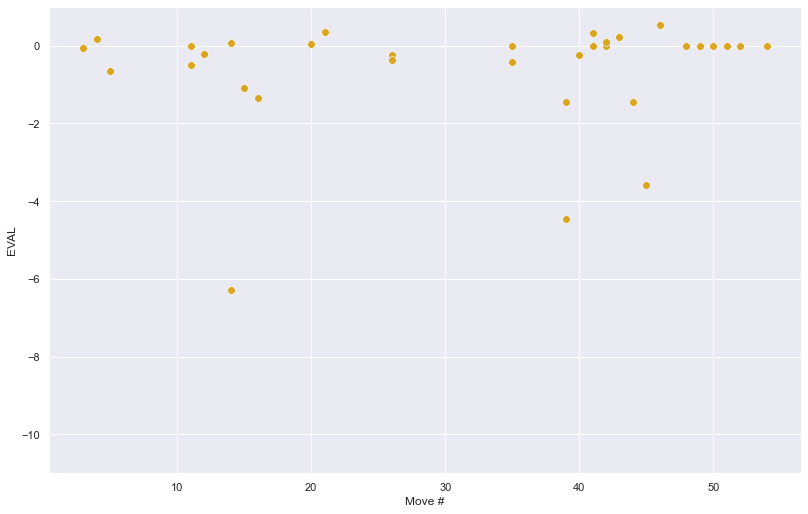

```
Queen Graph: -0.99, n=55
```

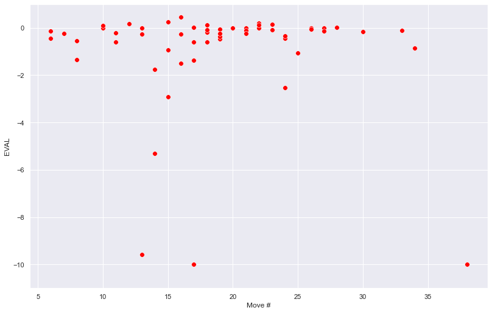

```
Rook Graph: -0.77, n=60
```

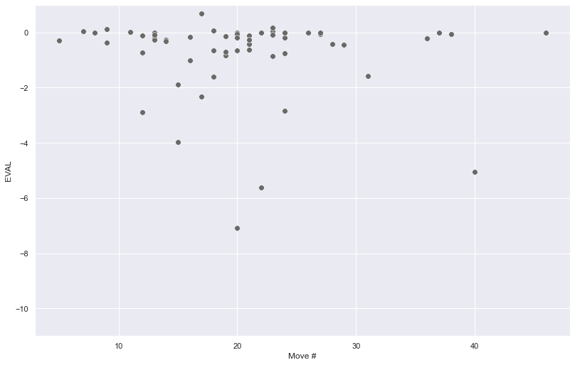

```
Bishop Graph: -0.86, n=90
```

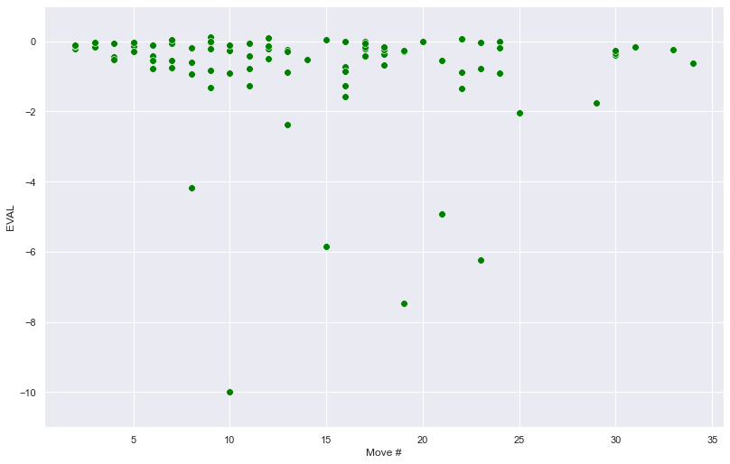

```
Knight Graph: -0.79, n=82
```

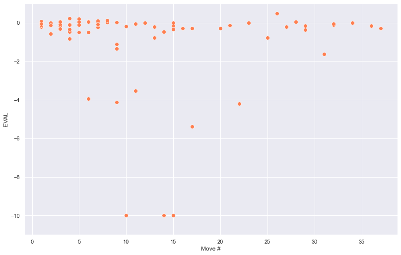

```
Pawn Graph: -0.51, n=127
```

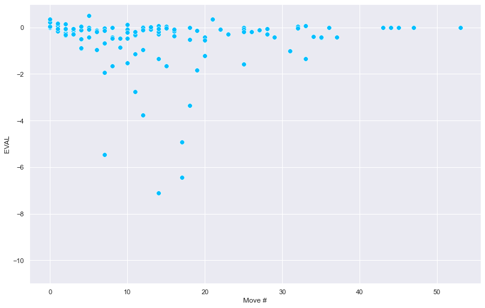

```
Castle Graph: -0.23, n=12
```

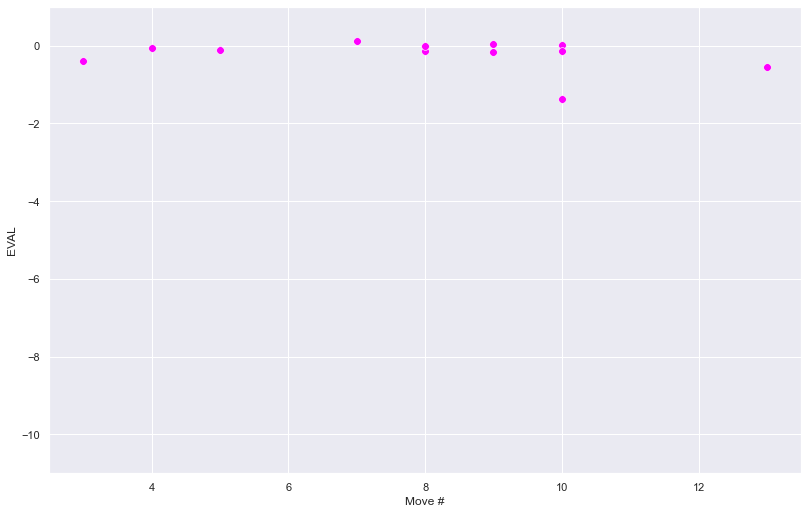

```python
def move_rating(df, side):
    df = df[df["Color"] == side].reset_index()
    if (side == "White"):
        colrat = "WhiteRating"
        colmove = "WhiteMoves"
        enemyrat = "BlackRating"
        enemymove = "BlackMoves"
        bottomLimit = -11
        upperLimit = 1
        maxRat = -10
    elif (side == "Black"):
        colrat = "BlackRating"
        colmove = "BlackMoves"
        enemyrat = "WhiteRating"
        enemymove = "WhiteMoves"
        bottomLimit = -1
        upperLimit = 11
        maxRat = 10
    else:
        raise ValueError("Invalid input.")

    turn = []
    rating = []
    piece = []
    capture=[]
    # for the table below the graphs
    K, Q, R, B, N, C, P, X, NX = [], [], [], [], [], [], [], [], []

    for j in np.arange(len(df[colrat])):
        for i in np.arange(len(df[colrat][j])):
            # Added x_jitter by random (0, 0.4)
            turn.append(i + np.random.rand() * 0.8)
            if (abs(df[colrat][j][i]) > 10):
                rating.append(maxRat)
            else:
                rating.append(df[colrat][j][i])

            # movedPiece represents the piece moved already with [0]
            # taking the first character of the string.
            # ex. 'B' from 'Bc4'
            movedPiece = df[colmove][j][i][0]
            capturePiece = df[colmove][j][i][1]


            if (movedPiece == 'K'):
                piece.append('King')
                K.append(rating[-1])
            elif (movedPiece == 'Q'):
                piece.append('Queen')
                Q.append(rating[-1])
            elif (movedPiece == 'R'):
                piece.append('Rook')
                R.append(rating[-1])
            elif (movedPiece == 'B'):
                piece.append('Bishop')
                B.append(rating[-1])
            elif (movedPiece == 'N'):
                piece.append('Knight')
                N.append(rating[-1])
            elif (movedPiece == 'O'):
                piece.append('Castle')
                C.append(rating[-1])
            else:
                piece.append('Pawn')
                P.append(rating[-1])

            if (capturePiece == 'x'):
                capture.append('Capture')
                X.append(rating[-1])
            else:
                capture.append('No capture')
                NX.append(rating[-1])


    # added this way after or probably would've written differently
    e_turn = []
    e_rating = []
    e_piece = []
    e_capture=[]
    eK, eQ, eR, eB, eN, eC, eP, eX, eNX = [], [], [], [], [], [], [], [], []

    for j in np.arange(len(df[enemyrat])):
        for i in np.arange(len(df[enemyrat][j])):
            # Added x_jitter by random (0, 0.4)
            e_turn.append(i)
            if (abs(df[enemyrat][j][i]) > 10):
                e_rating.append(maxRat * -1)
            else:
                e_rating.append(df[enemyrat][j][i])

            # movedPiece represents the piece moved already with [0]
            # taking the first character of the string.
            # ex. 'B' from 'Bc4'
            e_movedPiece = df[enemymove][j][i][0]
            e_capturePiece = df[enemymove][j][i][1]


            if (e_movedPiece == 'K'):
                e_piece.append('King')
                eK.append(e_rating[-1])
            elif (e_movedPiece == 'Q'):
                e_piece.append('Queen')
                eQ.append(e_rating[-1])
            elif (e_movedPiece == 'R'):
                e_piece.append('Rook')
                eR.append(e_rating[-1])
            elif (e_movedPiece == 'B'):
                e_piece.append('Bishop')
                eB.append(e_rating[-1])
            elif (e_movedPiece == 'N'):
                e_piece.append('Knight')
                eN.append(e_rating[-1])
            elif (e_movedPiece == 'O'):
                e_piece.append('Castle')
                eC.append(e_rating[-1])
            else:
                e_piece.append('Pawn')
                eP.append(e_rating[-1])

            if (e_capturePiece == 'x'):
                e_capture.append('Capture')
                eX.append(e_rating[-1])
            else:
                e_capture.append('No capture')
                eNX.append(e_rating[-1])

    ax = plt.subplot()
    sns.set(rc={'figure.figsize':(12, 8)})
    sns.scatterplot(x=turn, y=rating, hue=piece, s=60)
    plt.xlabel("Move #")
    plt.ylabel("EVAL")
    plt.show()

    ax = plt.subplot()
    sns.set(rc={'figure.figsize':(12, 8)})
    sns.scatterplot(x=turn, y=rating, hue=capture, s=60)
    plt.xlabel("Move #")
    plt.ylabel("EVAL")
    plt.show()

    # Print table
    print("USER IS: " + side)

    looper = [[K, eK, "King"], [Q, eQ, "Queen"], [R, eR, "Rook"], [B, eB, "Bishop"],
              [N, eN, "Knight"], [P, eP, "Pawn"], [C, eC, "Castle"], [X, eX, "Capture"], [NX, eNX, "No capture"]]
    piece_df = {"Piece":[], "Avg Rating":[], "Avg Opponent Rating":[], "Total Gain":[], "Count":[], "Opponent Count":[]}
    piece_df = pd.DataFrame(piece_df)
    for i in looper:
        new_row = {"Piece":i[2], "Avg Rating":round(np.average(i[0]), 2),
                  "Avg Opponent Rating":round(np.average(i[1]), 2),
                  "Total Gain":round((round(np.average(i[0]), 2) + round(np.average(i[1]), 2)) * (len(i[0]) + len(i[1])) / 2, 2),
                  "Count":len(i[0]),
                  "Opponent Count":len(i[1])}
        piece_df = piece_df.append(new_row, ignore_index = True)


    print(piece_df.set_index("Piece").to_markdown())


    for i in np.arange(6):
        print()



    # Individual plots now
    idf = pd.DataFrame([turn, rating, piece]).transpose()
    idf[1] = idf[1].astype(float)
    idf[0] = idf[0].astype(int)
    colors = ['goldenrod', 'red', 'dimgray', 'green', 'coral', 'deepskyblue', 'fuchsia']
    colorsCount = 0

    for i in ['King', 'Queen', 'Rook', 'Bishop', 'Knight', 'Pawn', 'Castle']:
        temp_idf = idf[idf[2] == i]

        print(i + " Graph: " + str(round(np.average(temp_idf[1]), 2)) + ", n=" + str(len(temp_idf)))
        ax = plt.subplot()
        sns.set(rc={'figure.figsize':(12, 8)})
        sns.scatterplot(x=temp_idf[0], y=temp_idf[1], s=60, color=colors[colorsCount])
        plt.xlabel("Move #")
        plt.ylabel("EVAL")
        plt.ylim(bottomLimit, upperLimit)
        plt.show()
        print("")
        print("")

        colorsCount += 1


move_rating(stock_df, user_color)
```

### 6.5 Specified Eval + Move Number Statistics

Given a certain eval rating and a move number, what is the winrate for the user?

**Goal**: There's not much to see here, but maybe you might find that your winrate is horrificly low under a certain engine evaluation, like -2 (indicating that you give up too easily). Or that you choke through leads a lot. Besides that, it's just a fun tool to try out.

**Important**: In addition to outputting winrate, you can also optionally output a dataframe and a list that shows the index of the games where the user converted a win or loss. For example, if you wanted to see games where you came back from a -5 engine evaluation, you could use the list of indices / dataframe and match them with your CSV. To match the indices with the CSV, you will have to add 2 to each index (the actual CSV file's first entry is at row 2, while it is 0 in our dataframe).

**Inputs**: A lot! Check the cell below for instructions.

```python
# Inputs here

# Any number works (up to abs(15))
EVAL_RATING = -1.2

# Type either "range" or "split"
range_or_split = "range"

# Range for eval rating. If EVAL_RATING = 1.4 and EVAL_RANGE = 0.2, then it finds
# games between 1.2 and 1.6 rating (inclusive).
# MUST BE POSITIVE!
EVAL_RANGE = 0.5

# Split for eval rating. If EVAL_RATING = 1.4 and SPLIT_UP = True, then take
# all evals greater than or equal to 1.4. If SPLIT_UP = False, then take those below or equal.
SPLIT_UP = True

# Specify move number
MOVE_NUMBER = 5

# "White" or "Black"
user_color = "White"





# Optional: output indices + a dataframe of the games in this eval range.

# Set to True or False.
output = True

# Type "Win", "Loss", or "Draw"
# in output_result for only games that were won, lost, or drawn, or anything
# else for all games.
output_result = "Win"
```

After inputs are ready, run the cell below.

```python
def eval_move(df, eval_rating, range_or_split, eval_range, split_up, move_number, output, side, output_result):

    df = df[df["Color"] == side].reset_index().drop(["level_0"], axis=1)

    if (side == "White"):
        ratin = "WhiteStockfish"
    elif (side == "Black"):
        ratin = "BlackStockfish"
    else:
        raise ValueError("Invalid Input on user_color.")

    droplist = []
    if (range_or_split == "range"):
        for i in np.arange(len(df[ratin])):

            if (len(df[ratin][i]) < move_number):
                droplist.append(i)

            elif (abs(df[ratin][i][move_number - 1] - eval_rating) > eval_range):
                #print(df[ratin][i][move_number - 1])
                droplist.append(i)

    elif (range_or_split == "split"):
        for i in np.arange(len(df[ratin])):
            if (len(df[ratin][i]) < move_number):
                droplist.append(i)
            elif (split_up and (df[ratin][i][move_number - 1] < eval_rating)):
                droplist.append(i)
            elif ((split_up == False) and (df[ratin][i][move_number - 1] > eval_rating)):
                droplist.append(i)
    else:
        raise ValueError("Invalid Input on range_or_split.")

    df = df.drop(df.index[droplist]).reset_index().drop(["level_0"], axis=1)

    for i in np.arange(len(df[ratin])):
        df[ratin][i] = df[ratin][i][move_number - 1]

    print(color.GREEN + "Eval Range: " + str(eval_rating - eval_range) + " <-> " + str(eval_rating + eval_range))
    print("Move Number: " + str(move_number))
    wl_helper(df, side)
    mean = np.mean(df["OpponentRating"])
    print("AVG ELO:\t" + str(round(mean, 3)))

    if (output == True):
        print("------------------")
        print("")

        if (output_result == "Win"):
            df = df[df["Win"] == 1]
        elif (output_result == "Loss"):
            df = df[df["Loss"] == 1]
        elif (output_result == "Draw"):
            df = df[df["Draw"] == 1]
        else:
            output_result = "All"

        print(color.END + "Indices from original dataframe (read right column) for " + output_result + ":")
        print(df["index"])
        return df


eval_move(stock_df, EVAL_RATING, range_or_split, EVAL_RANGE, SPLIT_UP, MOVE_NUMBER, output, user_color, output_result)
```

```
Eval Range: -1.7 <-> -0.7
Move Number: 5
White
GP:		2
Record:		1-1-0
PPG:		0.5
AVG ELO:	1738.5
------------------

Indices from original dataframe (read right column) for Win:
0    93
Name: index, dtype: int64
```

|  | index | Year | Month | Day | Color | Result | Moves | Opponent | Opening | Variation | ... | BlackTotalSeconds | WhiteTotalMinutes | BlackTotalMinutes | Win | Loss | Draw | Site | UTCDate | UTCTime | Termination |
| --- | --- | --- | --- | --- | --- | --- | --- | --- | --- | --- | --- | --- | --- | --- | --- | --- | --- | --- | --- | --- | --- |
| 0 | 93 | 2020 | 12 | 19 | White | 1.0 | 26 | rusemobile | Ponziani Opening | Jaenisch Counterattack | ... | [720, 718, 716, 714, 712, 704, 701, 700, 697, ... | [12.0, 11.983333333333333, 11.966666666666667,... | [12.0, 11.966666666666667, 11.933333333333334,... | 1 | 0 | 0 | https://lichess.org/uJ1PXkMt | 2020.12.19 | 02:13:37 | Normal |

1 rows × 40 columns

## 7. Time Analysis

Everything to do with clock times.

Covers:

**7.0**. Setup

**7.1**. Move # vs Time Spent

**7.2**. Move # vs Time Remaining

**7.3**. Engine Evaluation vs Time Spent

**7.4**. Move Rating vs Time Spent

**7.5**. Piece Moved vs Time Spent

(Optional) Note: I was going to add something time control + increment related as well but the reason I didn't was because I don't think showing time+increment vs winrate shows anything significant. Having a lower winrate in 5 minute games versus 15 minute games is more of a Blitz vs Classical issue, and the equivalent rating in Blitz and Classical are not the same, ex. a 1500 player in Blitz is better than a 1500 player in Classical.

### 7.0 Setup

Like with before, many games won't have time evals either, so filter by games that have time evals.

```python
def filter_time(df):
    droplist = []
    for i in np.arange(len(df["WhiteMinutes"])):
        if (df["WhiteMinutes"][i] == []):
            droplist.append(i)

    df = df.drop(df.index[droplist]).reset_index()
    return df

time_df = filter_time(df)
```

The general function needed for all the time graphs below. At the bottom of the cell below, specify what mode or time control + increment you want to look at for time analysis. If you want to include all games for any of them, just leave the variable as a "", ex. time = "". If you want a 10+5 control, then set time=10 and increment=5.

Note: the PGN often didn't provide moves or ratings past move 99, so they any 100+ move/ratings likely won't appear in the graphs later.

```python
def time_fn(df, mode, time, increment):
    if (mode != ""):
        df = df[df["Event"] == mode].reset_index().drop(["level_0"], axis=1)
    if (time != ""):
        df = df[df["Time"] == time].reset_index().drop(["level_0"], axis=1)
    if (increment != ""):
        df = df[df["Increment"] == increment].reset_index().drop(["level_0"], axis=1)

    if (len(df) == 0):
        print("No games found.")
        return

    user = []
    move = []
    timeSpent = []
    timeLeft = []
    pieces = []

    # The reason this is needed instead of just using timeSpent is because of an edge
    # case where checkmate happens instead of a forfeit/time-out. The clock will update for
    # the very last move, but no eval is shown, so the lengths of the two arrays will mismatch.
    timeStock = []
    stockfish = []
    ratin = []

    gameCount = 0

    dualColor = ["White", "Black"]
    dualSeconds = ["WhiteSeconds", "BlackSeconds"]
    dualTotalMinutes = ["WhiteTotalMinutes", "BlackTotalMinutes"]
    dualStockfish = ["WhiteStockfish", "BlackStockfish"]
    dualRatin = ["WhiteRating", "BlackRating"]
    dualPieces =["WhiteMoves", "BlackMoves"]

    for k in np.arange(2):
        for i in np.arange(len(df[dualSeconds[k]])):
            lenstock = len(df[dualStockfish[k]][i])
            gameCount += 1

            # Check if user is White for every game
            if (df["Color"][i] == dualColor[k]):
                side = "Self"
            else:
                side = "Opponent"

            # Check if stockfish %eval is included for this game (i).
            if (df[dualStockfish[k]][i] == []):
                stockInclude = False
            else:
                stockInclude = True

            for j in np.arange(len(df[dualSeconds[k]][i])):

                if (df[dualPieces[k]][i][j] != ""):
                    user.append(side)
                    move.append(j)
                    timeSpent.append(df[dualSeconds[k]][i][j])
                    timeLeft.append(df[dualTotalMinutes[k]][i][j])

                    try:
                        movedPiece = df[dualPieces[k]][i][j][0]
                    except IndexError:
                        print(i)
                        print(j)
                        print(df[dualPieces[k]][i])
                    if (movedPiece.islower()):
                        movedPiece = 'P'
                    pieces.append(movedPiece)

                if ((stockInclude == True) and (j < lenstock - 1)):
                    timeStock.append(df[dualSeconds[k]][i][j])
                    stockfish.append(df[dualStockfish[k]][i][j])
                    ratin.append(df[dualRatin[k]][i][j])




    idf = pd.DataFrame([move, timeSpent, timeLeft, user, stockfish, timeStock, ratin, pieces]).transpose()
    idf[0] = idf[0].astype(int)
    idf[1] = idf[1].astype(float)
    idf[2] = idf[2].astype(float)
    idf[4] = idf[4].astype(float)
    idf[5] = idf[5].astype(float)
    idf[6] = idf[6].astype(float)
    idf = idf.rename(columns={0:"move", 1:"timeSpent", 2:"timeLeft", 3:"user", 4:"stockfish",
                             5:"timeSpentStockfish", 6:"rating", 7:"pieces"})

    return idf, gameCount, stockfish



# EDIT HERE
mode = ""
time = ""
increment = ""




ta_df, gameCount, stock_time = time_fn(time_df, mode, time, increment)
```

### 7.1 Move # vs Time Spent

Compares the average time per move for a user and all opponents they played against.

**Goal**: See where in the game the user typically spends the most time thinking, and how they compare overall against opponents.

```
Game Count: 493.0
```

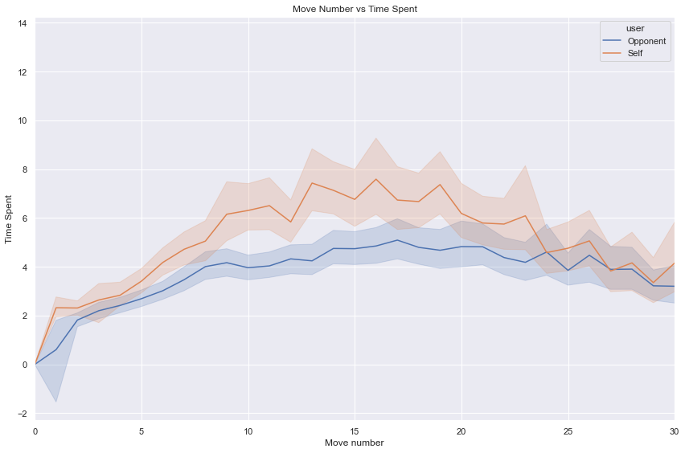

```python
print()
print(color.BOLD + "Game Count: " + str(gameCount / 2) + color.END)
print()

sns.lineplot(data=ta_df, x="move", y="timeSpent", hue="user", estimator=np.mean)
plt.xlabel("Move number")
plt.ylabel("Time Spent")
plt.xlim(0, 30)
plt.title("Move Number vs Time Spent")
plt.tight_layout()
plt.show()
```

### 7.2 Move # vs Time Remaining

Compares the average time left for a user and all opponents they played against.

**Goal**: See how a user chooses to budget their time in a game.

```
Game Count: 493.0
```

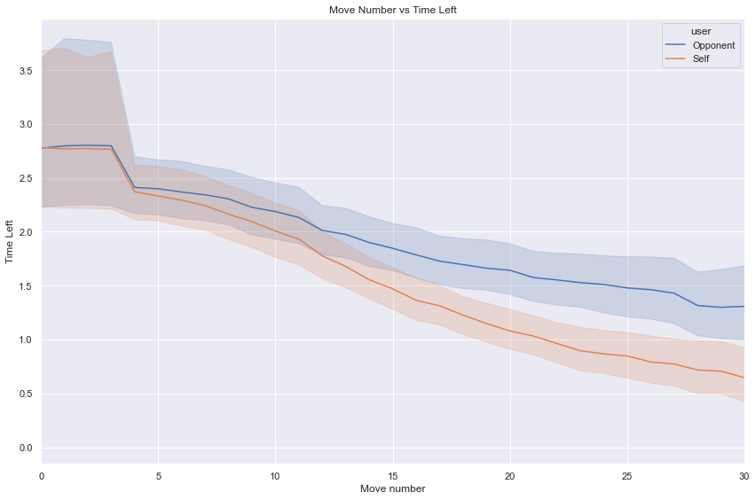

```python
print()
print(color.BOLD + "Game Count: " + str(gameCount / 2) + color.END)
print()


sns.lineplot(data=ta_df, x="move", y="timeLeft", hue="user", estimator=np.mean)
plt.xlabel("Move number")
plt.ylabel("Time Left")
plt.xlim(0, 30)
plt.title("Move Number vs Time Left")
plt.tight_layout()
plt.show()
```

### 7.3 Engine Evaluation vs Time Spent

Compares the current engine evaluation and how much time is spent on that move.

**Goal**: There's not much "good" or "bad" to see from this graph, but a difference between the user and opponent may say something about the user's habits when they are up or down on in the game.

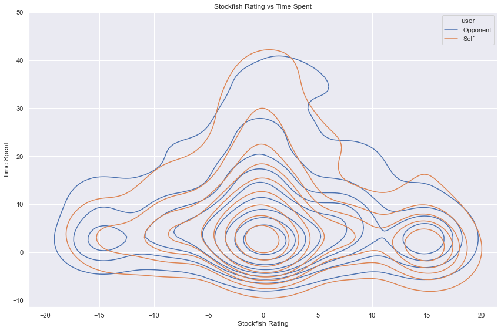

```python
if (len(stock_time) == 0):
        print("No games found with stockfish.")
else:
    sns.kdeplot(data=ta_df, x="stockfish", y="timeSpentStockfish", hue="user")
    plt.xlabel("Stockfish Rating")
    plt.ylabel("Time Spent")
    plt.title("Stockfish Rating vs Time Spent")
    plt.tight_layout()

    # Adjust the value if needed
    plt.ylim(top=50)

    plt.show()
```

### 7.4 Move Rating vs Time Spent

Compares the move's engine rating and how much time is spent on that move.

**Goal**: The focus on this graph is in the bad moves, or moves with negative ratings. Does the user typically spend less time thinking before making those moves? Or do they think a long time and still make the wrong move? Blunders are hard to make with a lot of thought, so if the user's curve is under the opponent's curve then they aren't spending enough time on moves (resulting in blunders).

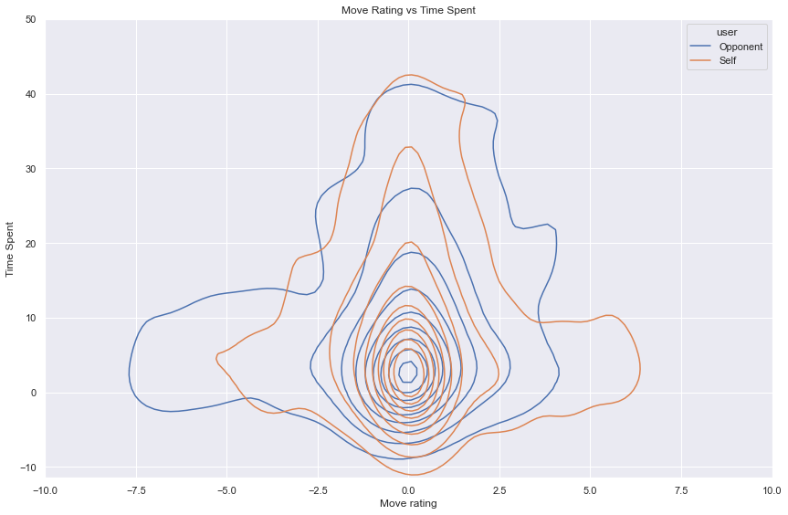

```python
if (len(stock_time) == 0):
    print("No games found with stockfish.")
else:
    sns.kdeplot(data=ta_df, x="rating", y="timeSpentStockfish", hue="user")
    plt.xlabel("Move rating")
    plt.ylabel("Time Spent")
    plt.title("Move Rating vs Time Spent")
    plt.tight_layout()

    # Adjust the value if needed
    plt.xlim(-10, 10)
    plt.ylim(top=50)

    plt.show()
```

### 7.5 Piece Moved vs Time Spent

Produces a graph for each piece and graphs move number vs the amount of time is spent in moving that piece.

**Goal**: There are many graphs here and the lines aren't very clear, but any extremely noticeable patterns indicate that the user has a particular habit with regards to moving a certain piece at a certain point in the game.

```
PIECE: B
```

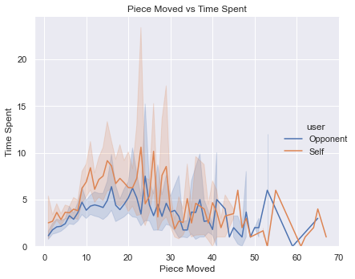

```
PIECE: K
```

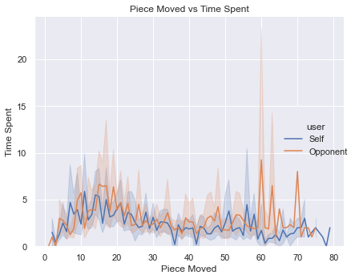

```
PIECE: N
```

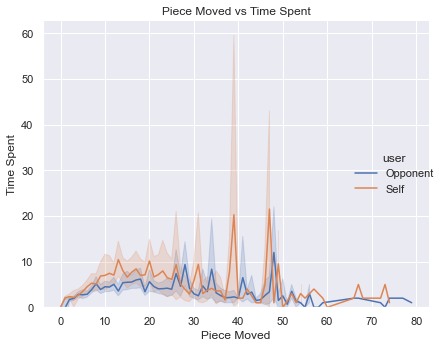

```
PIECE: O
```

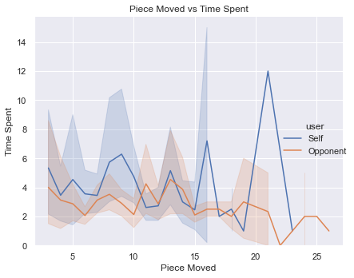

```
PIECE: P
```

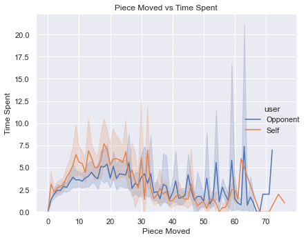

```
PIECE: Q
```

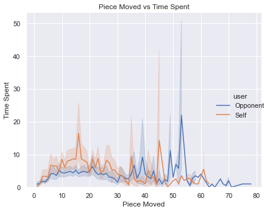

```
PIECE: R
```

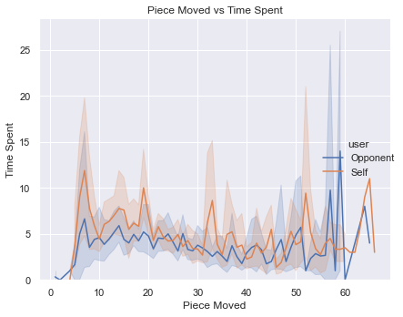

```python
uniquePieceList = np.unique(ta_df["pieces"])
for i in uniquePieceList:
    temp_idf = ta_df[ta_df["pieces"] == i]
    print("PIECE: " + i)
    sns.relplot(data=temp_idf, x="move", y="timeSpent", hue="user", kind="line")
    plt.xlabel("Piece Moved")
    plt.ylabel("Time Spent")
    plt.ylim(bottom=0)
    plt.title("Piece Moved vs Time Spent")
    plt.tight_layout()
    plt.show()
```

## 8. Seasons

Covers:

**8.1**. Seasons

**8.2**. Season Graphs

Feel free to skip this section, it's a very specific system that tracks data more than it really shows anything. Or you can run it if you want.

How I play rated on Lichess: every "season" consists of N=50 rated games, where I play in a specific rating range of range 150 (max - min) for Classical/Rapid only. After 50 games, the PPG (points per game) I get determines whether I keep the range the same, or promote/demote the range by +/-(50 * n) ELO points. For example, I might be playing on 1550-1700 in one season, and after promoting on a 29-19-2 season, I would be playing in the 1600-1750 range the next season.

**Goal**: Of course, since nobody else probably plays like this, the information above won't be very useful. Instead, what you can get out of this section is your performance for every N games (and especially, the most recent N games). It may also show how a user's opening repertoire has changed over time.

Note: used recursion to have the most recent season print first.

**Inputs**: N represents how long a season is (or every N games to show), and startELO and endELO represent the starting range for the first season.

```python
N = 50


startELO = 1550
endELO = 1700
```

### 8.1 Seasons

```python
def season_fn(df, start, end, season, gp):


    df = df.sort_values(["Year", "Month"], ascending = (False, False))

    score = np.sum(df[gp - N: gp]["Win"]) + 0.5 * np.sum(df[gp - N: gp]["Draw"])

    x, y, z = [], [], []

    if (gp >= 50):
        promote = ""
        magnitude = ""
        if (score >= 29):
            promote = "PROMOTION "
            magnitude = "+50"
            start += 50
            end += 50
            if (score >= 32.5):
                magnitude = "+100"
                start += 100
                end += 100
                if (score >= 36):
                    magnitude = "+150"
                    start += 150
                    end += 150
        if (score <= 21):
            promote = "DEMOTION "
            magnitude = "-50"
            start -= 50
            end -= 50
            if (score <= 32.5):
                magnitude = "-100"
                start -= 100
                end -= 100
                if (score <= 36):
                    magnitude = "-150"
                    start -= 150
                    end -= 150

        df50 = df[gp - N: gp]

        x, y, z = season_fn(df[0: gp - N], start, end, season + 1, gp - N)

    else:
        df50 = df
        promote = ""
        magnitude = ""

    x.append(season)
    y.append(np.mean(df["OpponentRating"]))
    z.append(score)

    wl_season(df50, "Season " + str(season), promote, magnitude, start, end, score)


    white = df50[df50["Color"] == "White"]
    black = df50[df50["Color"] == "Black"]


    print(color.BOLD + "WHITE:" + color.END)
    print(opening_list(white).iloc[0:5, [0, 2, 3, 4, 1, 8, 7]].to_markdown())

    print(color.BOLD + "BLACK:" + color.END)
    print(opening_list(black).iloc[0:5, [0, 2, 3, 4, 1, 8, 7]].to_markdown())
    print("")
    print("")
    print("")
    print("")

    gp -= N

    return x, y, z


def wl_season(data, event, promote, magnitude, start, end, score):

    print(color.UNDERLINE + color.DARKCYAN + event + color.END)
    print(color.RED + "Division:\t" + color.GREEN + str(start) + "-" + str(end))

    wl_helper(data, color.RED + "PTS:\t\t" + color.GREEN + str(score))

    mean = np.mean(data["OpponentRating"])
    print("AVG ELO:\t" + str(round(mean, 3)))

    if (promote != ""):
        print(color.PURPLE + promote + magnitude)

    print(color.END)



season_output = season_fn(df, startELO, endELO, 1, len(df))
```

```
Season 12
Division:	-1150--1000
PTS:		4.0
GP:		20
Record:		4-16-0
PPG:		0.2
AVG ELO:	1571.7

WHITE:
| Opening           |   GP |   Win |   Loss |   Draw |   Moves |   Rating Difference |   Total Rating Gain |
|:------------------|-----:|------:|-------:|-------:|--------:|--------------------:|--------------------:|
| Queen's Pawn Game |    4 |     2 |      2 |      0 |    24.5 |                -181 |                   9 |
| King's Pawn Game  |    2 |     1 |      1 |      0 |    28   |                -179 |                   5 |
| Russian Game      |    2 |     0 |      2 |      0 |    31   |                -316 |                  -4 |
| Ponziani Opening  |    1 |     0 |      1 |      0 |    23   |                 -57 |                  -5 |
BLACK:
| Opening          |   GP |   Win |   Loss |   Draw |   Moves |   Rating Difference |   Total Rating Gain |
|:-----------------|-----:|------:|-------:|-------:|--------:|--------------------:|--------------------:|
| Sicilian Defense |    3 |     1 |      2 |      0 |      21 |                -140 |                   1 |
| Scotch Game      |    2 |     0 |      2 |      0 |      27 |                -316 |                  -3 |
| Italian Game     |    1 |     0 |      1 |      0 |      28 |                 -41 |                  -5 |
| King's Pawn Game |    1 |     0 |      1 |      0 |       4 |                -116 |                  -3 |
| Mieses Opening   |    1 |     0 |      1 |      0 |      13 |                -515 |                  -1 |




Season 11
Division:	-1150--1000
PTS:		10.5
GP:		50
Record:		10-39-1
PPG:		0.21
AVG ELO:	1633.6
DEMOTION -150

WHITE:
| Opening           |   GP |   Win |   Loss |   Draw |   Moves |   Rating Difference |   Total Rating Gain |
|:------------------|-----:|------:|-------:|-------:|--------:|--------------------:|--------------------:|
| Four Knights Game |    4 |     2 |      2 |      0 |    24   |                -286 |                  14 |
```

[output cut: 285 more lines]

```
| Opening              |   GP |   Win |   Loss |   Draw |   Moves |   Rating Difference |   Total Rating Gain |
|:---------------------|-----:|------:|-------:|-------:|--------:|--------------------:|--------------------:|
| Philidor Defense     |    3 |     1 |      2 |      0 |    26.3 |                  75 |                 -92 |
| Scandinavian Defense |    3 |     2 |      1 |      0 |    20.7 |                   0 |                -115 |
| Alekhine Defense     |    2 |     0 |      2 |      0 |    23   |                -396 |                 -60 |
| French Defense       |    2 |     1 |      0 |      1 |    42   |                 -20 |                  91 |
| Ruy Lopez            |    2 |     2 |      0 |      0 |    12.5 |                -198 |                 176 |
BLACK:
| Opening               |   GP |   Win |   Loss |   Draw |   Moves |   Rating Difference |   Total Rating Gain |
|:----------------------|-----:|------:|-------:|-------:|--------:|--------------------:|--------------------:|
| King's Pawn Game      |    5 |     3 |      2 |      0 |    15.8 |                 107 |                 -28 |
| Bishop's Opening      |    3 |     0 |      3 |      0 |    31.3 |                  64 |                -124 |
| Italian Game          |    3 |     1 |      1 |      1 |    10.7 |                  23 |                  17 |
| Queen's Pawn Game     |    3 |     1 |      1 |      1 |    39.3 |                -324 |                 143 |
| King's Knight Opening |    2 |     1 |      1 |      0 |    34   |                  90 |                 -10 |
```

### 8.2 Season Graphs

The following cell plots the season in the x-axis, the average opponent ELO in the y-axis, and the score (wins + 0.5 * draws) in the z-axis. These were defined as x, y and z in the previous function and returned as the output of season_fn.

**Non-interactive version**:

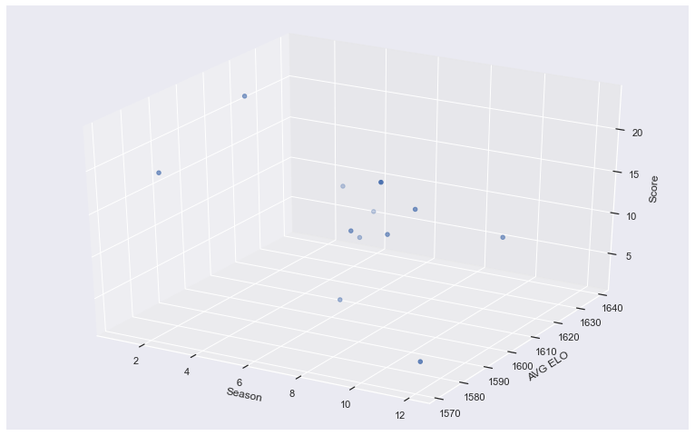

```python
fig = plt.figure()
ax = fig.add_subplot(111, projection = '3d')

x = season_output[0]
y = season_output[1]
z = season_output[2]

ax.set_xlabel("Season")
ax.set_ylabel("AVG ELO")
ax.set_zlabel("Score")

ax.scatter(x, y, z)

plt.show()
```

**Interactive version**:

```python
fig = px.scatter_3d(x=season_output[0], y=season_output[1], z=season_output[2],
                    range_x = [-3, max(x) + 3], range_y = [min(y) - 100, max(y) + 100], range_z = [-5, 55],
                   labels={
                     "x": "Season",
                    "y":"AVG ELO",
                       "z":"Score"
                     },
                    title="Opponent Elo vs W/L by Season")
fig.show()
```

[interactive chart not shown]

**2D version**:

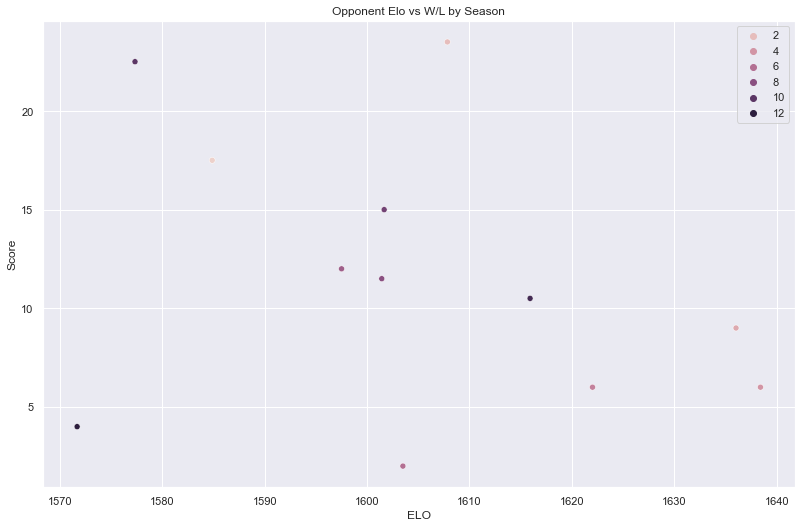

```python
#plt.figure(figsize=(13,8))

ax = sns.scatterplot(x=season_output[1], y=season_output[2], hue=season_output[0])
plt.draw()

plt.xlabel("ELO")
plt.ylabel("Score")
plt.title("Opponent Elo vs W/L by Season")
plt.show()
```

## 9. Win Predictor using PCA + Multinomial Logistic Regression

Covers:

**9.0**. PCA + Model

**9.1**. Model 1: Predictor using model_df

**9.2**. Model 2: Predictor without game knowledge

**9.3**. Model 3: Predictor with opening knowledge

### 9.0 PCA + Model

##### PCA

**Output**: Plotted the impact of each variable and a scree plot.

"PCA really shines on data where you have reason to believe that the data is relatively low in rank."

Results may differ based on what chess dataset you use, but it seems that in virtually all cases, all the variables used for PCA seem to be indepedent, or in other words, the data is already high in rank and cannot be reduced further down.

**Note**: If you don't have model_df or don't want to use it, comment out the last two lines of the cell below (with #) and skip section 9.1.